# PSC study: Q1

# 1. Hypothesis: PSC is associated with the gut microbiome changes.

## Introduction

**Pre_LTx vs Post_LTx vs Healthy analysis on merged data**

- Alpha diversity – Richness, Shannon, Simpson, and Pielou indices tested by linear fixed effect or mixed effect model (group effect, country effect, interaction effect)
- Beta diversity – PERMANOVA (group effect, country effect, interaction effect), PCA visualization
- Differential abundance testing:
  - o Group effect – linDA + MaAsLin2 intersection
  - o Country effect – taxa with significant interaction effect were excluded based on individual post-hoc analysis. Taxa had to have the same direction in both countries
- ML models, trained and validated using out-of-sample bootstrap (500 resamplings):

o ENET

o kNN

o GBoost

o RF

Pairwise comparisons:

**Pre_ltx vs Healthy** – an effect of disease, liver cirrhosis and overall bad clinical condition

**Pre_ltx vs post_ltx** – an effect of transplantation + general improvement of the clinical state

**Post_ltx vs Healthy** – does LTx lead to „healthy microbiome”?

**Report structure** The analysis is divided into two segments: terminal ileum and colon. Each part begins with data filtering, where sequencing depth is assessed and nearZeroVar() is applied to remove taxa with no variance in the dataset. This is followed by a series of analytical steps:

1. Alpha diversity
2. Beta diversity
3. Univariate testing
4. Machine learning models training and validation

At the end of the analysis, a brief summary of the results is provided.

**Importing libraries and custom functions built for this analysis**

```r
source("custom_functions.R")
```

## Clinical characteristics

```r
clinical_char <- read.xlsx("../results/clinical_characteristics.xlsx",
                           colNames = FALSE)
colnames(clinical_char) <- clinical_char[3,]
clinical_char <- clinical_char[-c(1,2,3),]
header_groups <- c(" " = 2, "HC" = 2, "pre_LTx" = 2, "post_LTx_non-rPSC"=2, "post_LTx_rPSC"=2)
```

```r
knitr::kable(clinical_char, align="l", escape=FALSE,digits=3) %>%
  kable_styling(bootstrap_options = c("hover", "striped", "responsive")) %>%
  kable_styling(full_width = TRUE) %>%
  add_header_above(header_groups)
```

HC

pre_LTx

post_LTx_non-rPSC

post_LTx_rPSC

NA

Norway

Czech

Norway

Czech

Norway

Czech

Norway

Czech

4

F/M [n]

10/30

30/26

19/65

12/19

15/36

26/57

13

3/22

5

Age [years]

NA

50 (23;68)

40 (17;77)

35 (17;63)

49 (23;70)

48 (32;81)

NA

48 (26;81)

6

IBD yes/no [n]

66/18

25/6

31/7

72/11

11/2

24/1

7

Total bilirubin [µmol/l]

21 (3;68)

24

62 (9;500)

19.5 (11;49)

18 (5;132)

24 (13;52)

24 (6;148)

8

AST [µkat/l]

0.5 (0.3;1.9)

1.1 (0.2;8.6)

1.6 (0.5;4.0)

0.6 (0.2;3.2)

0.4 (0.2;1.7)

1.1 (0.3, 4.0)

0.5 (0.2;1.9)

9

ALT [µkat/l]

0.5 (0.3;1.7)

1.6 (0.5;8.6)

1.7 (0.5;5.2)

0.6 (0.1,4.1)

0.5 (0.3;4.0)

1.1 (0.2;4.5)

0.5 (0.3;3.5)

10

ALP [µkat/l]

1.3 (0.7;2.3)

4.2 (0.9;17.3)

6.0 (1.6;17.8)

1.3 (0.6;7.9)

1.4 (0.6;3.5)

3.7 (0.5;13.9)

2.3 (0.5;13.1)

11

GGT [µkat/l]

0.4 (0.2;5.0)

2.6 (0.6;15.2)

0.4 (0.1; 4.8)

1.4 (0.3;13.7)

12

INR [-]

1.1 (1.1;1.2)

1.1 (0.9;1.8)

1.1 (0.9;1.6)

1.1 (1.0;1.7)

13

Creatinine [µmol/l]

77 (50;115)

65 (39; 232)

60 (44;101)

84 (59; 159)

87 (49;248)

81 (65; 133)

85 (50;780)

14

Albumin [g/l]

50 (43;57)

41 (26;49)

38 (20;50)

43 (35;49)

45 (26;51)

38 (34; 50)

42 (26;50)

15

Fecal calprotectin [µg/g]

59 (1;2844)

123 (6;4513)

30 (1;1945)

275 (6;4821)

55 (10;832)

564 (14;4301)

16

NANCY_max [-]

2 (0;4)

2 (0;4)

2 (0;4)

17

eMayo [-]

1 (0;2)

1 (0;3)

1 (0;2)

18

Mayo_DAI [-]

2 (0;5)

1 (0;8)

2 (0;7)

19

Mayo_PSC risk score [-]

0.3 (;2.2;3.5)

0.3 (;2.2;3.5)

0.3 (;1.1;2.2)

1.0 (;1.4;3.1)

20

AOM_score [-]

1.9 (0.5;3.8)

2 (1.1;5.0)

1.9 (0.8;2.7)

2.2 (1.2;3.5)

21

APRI_score [-]

0.2 (0.1;1.5)

0.7 (0.1;5.5)

1.1 (0.3;14.3)

0.5 (0.2;2.3)

0.3 (0.1;1.5)

0.7 (0.2;3.6)

0.4 (0.1;1.4)

22

FIB-4_score [-]

0.8 (0.4;3.4)

1.1 (0.8;8.6)

1.6 (0.4;23.1)

1.5 (0.6;3.6)

1.1 (0.3; 5.0)

2.2 (0.5;5.8)

1.1 (0.5;3.1)

23

MELD_score [-]

7.8 (7.1;8.6)

8.2 (6.4;18.0)

8.0 (6.4;14.6)

7.8 (6.5;22.8)

24

Platelets [10^9/l]

267 (145;400)

265 (37; 712)

201 (20;477)

197 (101;434)

208 (41;442)

212 (69;409)

213 (83;416)

## Data Import

Importing ASV, taxa and metadata tables for both Czech and Norway samples.

**Czech**

```r
path = "../../data/analysis_ready_data/ikem/"
asv_tab_ikem <- as.data.frame(fread(file.path(path,"asv_table_ikem.csv"),
                                    check.names = FALSE))
taxa_tab_ikem <- as.data.frame(fread(file.path(path,"taxa_table_ikem.csv"),
                                     check.names = FALSE))
metadata_ikem <- as.data.frame(fread(file.path(path,"metadata_ikem.csv"),
                                     check.names = FALSE))
```

**Norway**

```r
path = "../../data/analysis_ready_data/norway/"
asv_tab_norway <- as.data.frame(fread(file.path(path,"asv_table_norway.csv"),
                                    check.names = FALSE))
taxa_tab_norway <- as.data.frame(fread(file.path(path,"taxa_table_norway.csv"),
                                    check.names = FALSE))
metadata_norway <- as.data.frame(fread(file.path(path,"metadata_norway.csv"),
                                    check.names = FALSE))
```

## Merging

Merging two countries based on the different matrices - Ileum, Colon.

**Terminal ileum**

```r
ileum_data <- merging_data(asv_tab_1=asv_tab_ikem,
                           asv_tab_2=asv_tab_norway,
                           taxa_tab_1=taxa_tab_ikem,
                           taxa_tab_2=taxa_tab_norway,
                           metadata_1=metadata_ikem,
                           metadata_2=metadata_norway,
                           segment="TI",Q="Q1")
```

```
## Removing 1498 ASV(s)
```

```
## Removing 1834 ASV(s)
```

```
## Merging at ASV level
```

```
## Finding inconsistencies in taxonomy, trying to keep the ones that have better taxonomy assignment
```

```r
ileum_asv_tab <- ileum_data[[1]]
ileum_taxa_tab <- ileum_data[[2]]
ileum_metadata <- ileum_data[[3]]
```

**Reads statistics**

```r
summary(colSums(ileum_asv_tab[,-1]))
```

```
##    Min. 1st Qu.  Median    Mean 3rd Qu.    Max.
##    3441   16579   20972   24071   28473   85910
```

**Colon**

```r
colon_data <- merging_data(asv_tab_1=asv_tab_ikem,
                           asv_tab_2=asv_tab_norway,
                           taxa_tab_1=taxa_tab_ikem,
                           taxa_tab_2=taxa_tab_norway,
                           metadata_1=metadata_ikem,
                           metadata_2=metadata_norway,
                           segment="colon",Q="Q1")
```

```
## Removing 739 ASV(s)
```

```
## Removing 266 ASV(s)
```

```
## Merging at ASV level
```

```
## Finding inconsistencies in taxonomy, trying to keep the ones that have better taxonomy assignment
```

```r
colon_asv_tab <- colon_data[[1]]
colon_taxa_tab <- colon_data[[2]]
colon_metadata <- colon_data[[3]]
```

**Reads statistics**

```r
summary(colSums(colon_asv_tab[,-1]))
```

```
##    Min. 1st Qu.  Median    Mean 3rd Qu.    Max.
##      63   19814   26676   30841   37553  136048
```

# Data Analysis - Terminal ileum

```r
segment="terminal_ileum"
```

## Filtering

Rules:

- sequencing depth > 10000
- nearZeroVar() with default settings

**Rarefaction Curve**

```r
path="../intermediate_files/rarecurves"
seq_depth_threshold <- 10000
```

```r
ps <- construct_phyloseq(ileum_asv_tab,ileum_taxa_tab,ileum_metadata)
rareres <- get_rarecurve(obj=ps, chunks=500)
save(rareres,file = file.path(path,"rarefaction_ileum.Rdata"))
```

```r
load(file.path(path,"rarefaction_ileum.Rdata"))

prare <- ggrarecurve(obj=rareres,
                      factorNames="Country",
                      indexNames=c("Observe")) +
  theme_bw() +
  theme(axis.text=element_text(size=8), panel.grid=element_blank(),
        strip.background = element_rect(colour=NA,fill="grey"),
        strip.text.x = element_text(face="bold")) +
  geom_vline(xintercept = seq_depth_threshold,
             linetype="dashed",
             color = "red") +
  xlim(0, 20000)
```

```
## The color has been set automatically, you can reset it manually by adding scale_color_manual(values=yourcolors)
```

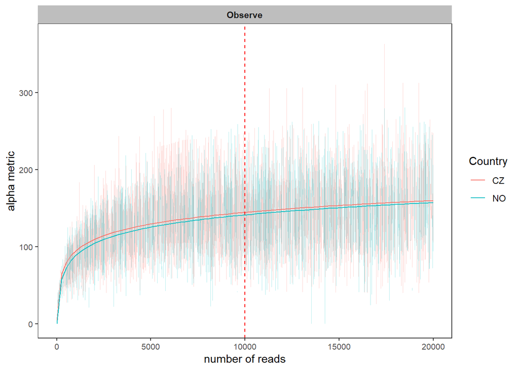

```r
prare
```

**Library size**

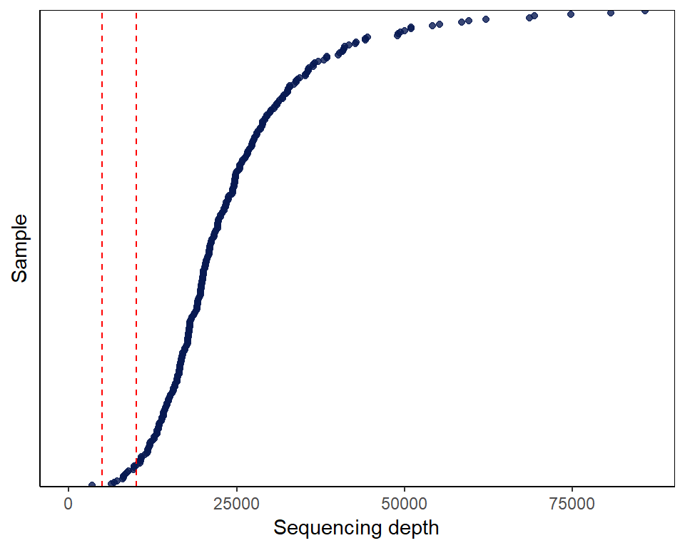

```r
read_counts(ileum_asv_tab, line = c(5000,10000))
```

### Sequencing depth

```r
data_filt <- seq_depth_filtering(ileum_asv_tab,
                                 ileum_taxa_tab,
                                 ileum_metadata,
                                 seq_depth_threshold = 10000)
```

```
## Removing 131 ASV(s)
```

```r
filt_ileum_asv_tab <- data_filt[[1]]; alpha_ileum_asv_tab <- filt_ileum_asv_tab
filt_ileum_taxa_tab <- data_filt[[2]]; alpha_ileum_taxa_tab <- filt_ileum_taxa_tab
filt_ileum_metadata <- data_filt[[3]]; alpha_ileum_metadata <- filt_ileum_metadata

seq_step <- dim(filt_ileum_asv_tab)[1]
```

**Library size**

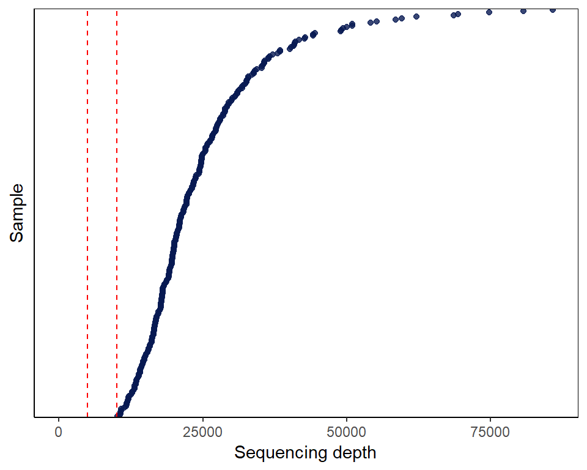

```r
read_counts(filt_ileum_asv_tab,line = c(5000,10000))
```

### NearZeroVar

```r
data_filt <- nearzerovar_filtering(filt_ileum_asv_tab,
                                   filt_ileum_taxa_tab,
                                   filt_ileum_metadata)

filt_ileum_asv_tab <- data_filt[[1]]
filt_ileum_taxa_tab <- data_filt[[2]]
nearzero_step <- dim(filt_ileum_asv_tab)[1]
```

**Library size**

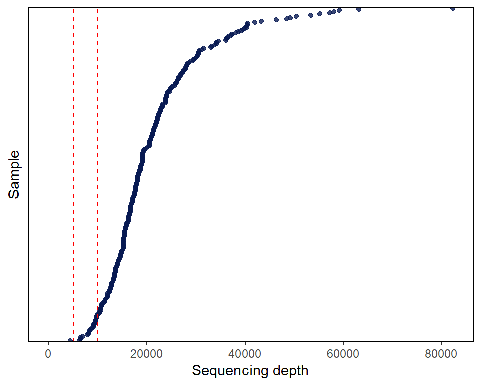

```r
read_counts(filt_ileum_asv_tab,line = c(5000,10000))
```

### Final Counts

```r
final_counts_filtering(ileum_asv_tab,
                       filt_ileum_asv_tab,
                       filt_ileum_metadata,
                       seq_step, 0, nearzero_step) %>% `colnames<-`("Count")
```

|  | Count |
| --- | --- |
| Raw data: ASVs | 5132 |
| Raw data: Samples | 294 |
| Sequencing depth filt: ASVs | 5001 |
| Prevalence filt: ASVs | 0 |
| NearZeroVar filt: ASVs | 479 |
| Filt data: ASVs | 479 |
| Filt data: Samples | 281 |
| Filt data: Patients | 281 |
| Filt data: Patients.1 | 0 |
| Filtered samples | 13 |

[output cut: 7 more lines]

## Alpha diversity

Calculating Richness, Shannon, Simpson, Pielou indexes on raw (unfiltered) rarefied data. Samples with sequencing depth < 10000 were excluded. Testing by linear model.

```r
path = "../results/Q1/alpha_diversity"
```

**Calculation**

```r
# Construct MPSE object
alpha_ileum_metadata$Sample <- alpha_ileum_metadata$SampleID
ileum_mpse <- as.MPSE(construct_phyloseq(alpha_ileum_asv_tab,
                                         alpha_ileum_taxa_tab,
                                         alpha_ileum_metadata))

ileum_mpse %<>% mp_rrarefy(raresize = 10000,seed = 123)

# Calculate alpha diversity - rarefied counts
ileum_mpse %<>% mp_cal_alpha(.abundance=RareAbundance, force=TRUE)
```

```r
alpha_div_plots <- list()

# preparing data frame
alpha_data <- data.frame(SampleID=ileum_mpse$Sample.x,
                         Observe=ileum_mpse$Observe,
                         Shannon=ileum_mpse$Shannon,
                         Simpson=ileum_mpse$Simpson,
                         Pielou=ileum_mpse$Pielou,
                         Group=ileum_mpse$Group,
                         Country=ileum_mpse$Country,
                         Patient=ileum_mpse$Patient)

# save the result
write.csv(alpha_data,file.path(path,paste0("alpha_indices_",segment,".csv")),
          row.names = FALSE)
```

### Plots

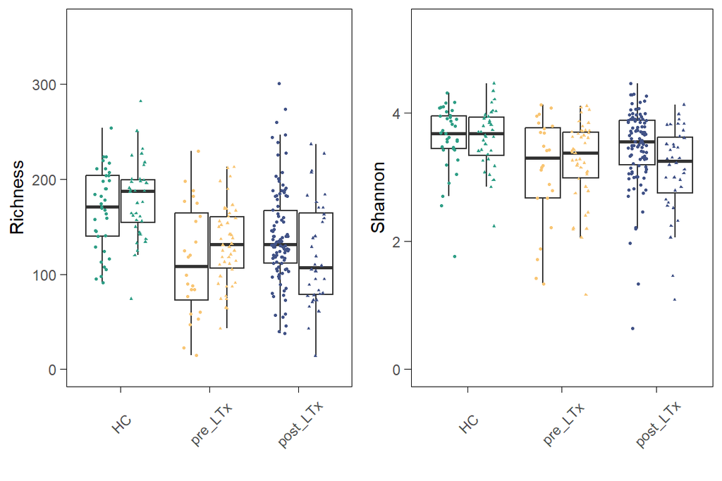

```r
p_boxplot_alpha <- alpha_diversity_countries(alpha_data)
# save the results
alpha_div_plots[[paste(segment,"Country")]] <- p_boxplot_alpha

# see the results
p_boxplot_alpha
```

### Linear Models

```r
path = "../results/Q1/alpha_diversity"
alpha_data <- read.csv(file.path(path,paste0("alpha_indices_",segment,".csv")))
```

**Richness**

```r
# run model
results_model <- pairwise.lm(formula = "Observe ~ Group * Country",
                             factors=alpha_data$Group,
                             data=alpha_data)

# check interaction
if (!is.data.frame(results_model)){
  results_model_observe <- results_model[[1]]
  results_model_observe_emeans <- results_model[[2]]
} else {
  results_model_observe <- results_model
  results_model_observe_emeans <- NA
}

# save the results
pc_observed <- list();
pc_observed[[segment]] <- results_model_observe
```

```r
# see the results
knitr::kable(results_model_observe,digits = 3,
caption = "Raw results of linear model of richness estimation.")
```

Raw results of linear model of richness estimation.

|  | Estimate | Std..Error | t.value | Pr…t.. | p.adj | sig |
| --- | --- | --- | --- | --- | --- | --- |
| healthy vs Grouppre_ltx | -53.642 | 11.742 | -4.568 | 0.000 | 0.000 | *** |
| healthy , pre_ltx - CZ vs NO | 11.219 | 10.488 | 1.070 | 0.287 | 0.361 |  |
| healthy vs Grouppre_ltx:CountryNO | 6.313 | 15.403 | 0.410 | 0.683 | 0.683 |  |
| pre_ltx vs Grouppost_ltx | 25.623 | 11.366 | 2.254 | 0.025 | 0.057 |  |
| pre_ltx , post_ltx - CZ vs NO | 17.533 | 12.615 | 1.390 | 0.166 | 0.249 |  |
| pre_ltx vs Grouppost_ltx:CountryNO | -35.933 | 15.921 | -2.257 | 0.025 | 0.057 |  |
| healthy vs Grouppost_ltx | -28.019 | 9.237 | -3.033 | 0.003 | 0.012 | * |
| healthy , post_ltx - CZ vs NO | 11.219 | 11.267 | 0.996 | 0.321 | 0.361 |  |
| healthy vs Grouppost_ltx:CountryNO | -29.620 | 14.629 | -2.025 | 0.044 | 0.080 |  |

```r
knitr::kable(results_model_observe_emeans,digits = 3,
caption = "Raw results of independent country analysis")
```

Raw results of independent country analysis

| contrast | Country | estimate | SE | df | t.ratio | p.value |
| --- | --- | --- | --- | --- | --- | --- |
| post_ltx - pre_ltx | CZ | 25.623 | 11.366 | 204 | 2.254 | 0.025 |
| post_ltx - pre_ltx | NO | -10.310 | 11.148 | 204 | -0.925 | 0.356 |
| post_ltx - healthy | CZ | -28.019 | 9.237 | 207 | -3.033 | 0.003 |
| post_ltx - healthy | NO | -57.639 | 11.344 | 207 | -5.081 | 0.000 |

**Shannon**

```r
# run model
results_model <- pairwise.lm(formula = "Shannon ~ Group * Country",
                             factors=alpha_data$Group,
                             data=alpha_data)

# check interaction
if (!is.data.frame(results_model)){
  results_model_shannon <- results_model[[1]]
  results_model_shannon_emeans <- results_model[[2]]
} else {
  results_model_shannon <- results_model
  results_model_shannon_emeans <- NA
}

# save the results
pc_shannon <- list();
pc_shannon[[segment]] <- as.data.frame(results_model_shannon)
```

```r
# see the results
knitr::kable(results_model_shannon,digits = 3,
caption = "Raw results of linear model of Shannon estimation.")
```

Raw results of linear model of Shannon estimation.

|  | Estimate | Std..Error | t.value | Pr…t.. | p.adj | sig |
| --- | --- | --- | --- | --- | --- | --- |
| healthy vs Grouppre_ltx | -0.505 | 0.159 | -3.171 | 0.002 | 0.017 | * |
| healthy , pre_ltx - CZ vs NO | 0.007 | 0.142 | 0.046 | 0.963 | 0.963 |  |
| healthy vs Grouppre_ltx:CountryNO | 0.144 | 0.209 | 0.687 | 0.493 | 0.634 |  |
| pre_ltx vs Grouppost_ltx | 0.372 | 0.148 | 2.514 | 0.013 | 0.049 | * |
| pre_ltx , post_ltx - CZ vs NO | 0.150 | 0.164 | 0.915 | 0.361 | 0.542 |  |
| pre_ltx vs Grouppost_ltx:CountryNO | -0.502 | 0.207 | -2.423 | 0.016 | 0.049 | * |
| healthy vs Grouppost_ltx | -0.134 | 0.111 | -1.200 | 0.231 | 0.416 |  |
| healthy , post_ltx - CZ vs NO | 0.007 | 0.136 | 0.048 | 0.962 | 0.963 |  |
| healthy vs Grouppost_ltx:CountryNO | -0.358 | 0.176 | -2.031 | 0.044 | 0.098 |  |

```r
knitr::kable(results_model_shannon_emeans,digits = 3,
caption = "Raw results of independent country analysis")
```

Raw results of independent country analysis

| contrast | Country | estimate | SE | df | t.ratio | p.value |
| --- | --- | --- | --- | --- | --- | --- |
| post_ltx - pre_ltx | CZ | 0.372 | 0.148 | 204 | 2.514 | 0.013 |
| post_ltx - pre_ltx | NO | -0.130 | 0.145 | 204 | -0.898 | 0.370 |
| post_ltx - healthy | CZ | -0.134 | 0.111 | 207 | -1.200 | 0.231 |
| post_ltx - healthy | NO | -0.492 | 0.137 | 207 | -3.597 | 0.000 |

**Simpson**

```r
# run model
results_model <- pairwise.lm(formula = "Simpson ~ Group * Country",
                                     factors=alpha_data$Group,
                                     data=alpha_data)

# check interaction
if (!is.data.frame(results_model)){
  results_model_simpson <- results_model[[1]]
  results_model_simpson_emeans <- results_model[[2]]
} else {
  results_model_simpson <- results_model
  results_model_simpson_emeans <- NA
}


# save the results
pc_simpson <- list();
pc_simpson[[segment]] <- as.data.frame(results_model_simpson)
```

```r
# see the results
knitr::kable(results_model_simpson,digits = 3,
caption = "Raw results of linear model of Simpson estimation.")
```

Raw results of linear model of Simpson estimation.

|  | Estimate | Std..Error | t.value | Pr…t.. | p.adj | sig |
| --- | --- | --- | --- | --- | --- | --- |
| healthy vs Grouppre_ltx | -0.046 | 0.019 | -2.481 | 0.014 | 0.129 |  |
| healthy , pre_ltx - CZ vs NO | -0.008 | 0.017 | -0.466 | 0.642 | 0.692 |  |
| healthy vs Grouppre_ltx:CountryNO | 0.027 | 0.024 | 1.092 | 0.277 | 0.498 |  |
| pre_ltx vs Grouppost_ltx | 0.037 | 0.021 | 1.763 | 0.079 | 0.238 |  |
| pre_ltx , post_ltx - CZ vs NO | 0.019 | 0.023 | 0.811 | 0.418 | 0.627 |  |
| pre_ltx vs Grouppost_ltx:CountryNO | -0.060 | 0.029 | -2.033 | 0.043 | 0.195 |  |
| healthy vs Grouppost_ltx | -0.009 | 0.016 | -0.572 | 0.568 | 0.692 |  |
| healthy , post_ltx - CZ vs NO | -0.008 | 0.020 | -0.396 | 0.692 | 0.692 |  |
| healthy vs Grouppost_ltx:CountryNO | -0.033 | 0.025 | -1.303 | 0.194 | 0.436 |  |

```r
knitr::kable(results_model_simpson_emeans,digits = 3,
caption = "Raw results of independent country analysis")
```

Raw results of independent country analysis

| contrast | Country | estimate | SE | df | t.ratio | p.value |
| --- | --- | --- | --- | --- | --- | --- |
| post_ltx - pre_ltx | CZ | 0.037 | 0.021 | 204 | 1.763 | 0.079 |
| post_ltx - pre_ltx | NO | -0.023 | 0.021 | 204 | -1.106 | 0.270 |

**Pielou**

```r
# run model
results_model <- pairwise.lm(formula = "Pielou ~ Group * Country",
                                     factors=alpha_data$Group,
                                     data=alpha_data)

# check interaction

if (!is.data.frame(results_model)){
  results_model_pielou <- results_model[[1]]
  results_model_pielou_emeans <- results_model[[2]]
} else {
  results_model_pielou <- results_model
  results_model_pielou_emeans <- NA
}

# save the results
pc_pielou <- list();
pc_pielou[[segment]] <- as.data.frame(results_model_pielou)
```

```r
# see the results
knitr::kable(results_model_pielou,digits = 3,
caption = "Raw results of linear model of Pielou estimation.")
```

Raw results of linear model of Pielou estimation.

|  | Estimate | Std..Error | t.value | Pr…t.. | p.adj | sig |
| --- | --- | --- | --- | --- | --- | --- |
| healthy vs Grouppre_ltx | -0.040 | 0.024 | -1.708 | 0.090 | 0.285 |  |
| healthy , pre_ltx - CZ vs NO | -0.008 | 0.021 | -0.394 | 0.694 | 0.943 |  |
| healthy vs Grouppre_ltx:CountryNO | 0.010 | 0.031 | 0.332 | 0.740 | 0.943 |  |
| pre_ltx vs Grouppost_ltx | 0.042 | 0.022 | 1.922 | 0.056 | 0.285 |  |
| pre_ltx , post_ltx - CZ vs NO | 0.002 | 0.024 | 0.082 | 0.935 | 0.943 |  |
| pre_ltx vs Grouppost_ltx:CountryNO | -0.051 | 0.030 | -1.677 | 0.095 | 0.285 |  |
| healthy vs Grouppost_ltx | 0.001 | 0.017 | 0.072 | 0.943 | 0.943 |  |
| healthy , post_ltx - CZ vs NO | -0.008 | 0.020 | -0.407 | 0.684 | 0.943 |  |
| healthy vs Grouppost_ltx:CountryNO | -0.041 | 0.027 | -1.525 | 0.129 | 0.290 |  |

```r
knitr::kable(results_model_pielou_emeans,digits = 3,
caption = "Raw results of independent country analysis")
```

Raw results of independent country analysis

| contrast | Country | estimate | SE | df | t.ratio | p.value |
| --- | --- | --- | --- | --- | --- | --- |
| post_ltx - pre_ltx | CZ | 0.042 | 0.022 | 204 | 1.922 | 0.056 |
| post_ltx - pre_ltx | NO | -0.009 | 0.021 | 204 | -0.435 | 0.664 |

### Saving results

```r
alpha_list <- list(
  Richness=pc_observed[[segment]] %>% rownames_to_column("Comparison"),
  Shannon=pc_shannon[[segment]] %>% rownames_to_column("Comparison"),
  Simpson=pc_simpson[[segment]] %>% rownames_to_column("Comparison"),
  Pielou=pc_pielou[[segment]] %>% rownames_to_column("Comparison"))

write.xlsx(alpha_list,
           file = file.path(path,paste0("alpha_diversity_results_",segment,".xlsx")))
```

## Beta diversity

Calculating Aitchison distance (euclidean distance on clr-transformed data) at genus level (main analysis). In supplements, there are also bray-curtis and Jaccard distance at ASV and genus levels. Testing by PERMANOVA.

### Main analysis

**Genus level, Aitchison distance**

```r
level="genus"
path = "../results/Q1/beta_diversity"
```

```r
pairwise_aitchison_raw <- list()
pca_plots_list <- list()
```

Aggregation, filtering

```r
# Aggregation
genus_data <- aggregate_taxa(ileum_asv_tab,
                             ileum_taxa_tab,
                             taxonomic_level=level,
                             names=TRUE)
# Filtration
filt_data <- filtering_steps(genus_data[[1]],
                             genus_data[[2]],
                             ileum_metadata,
                             seq_depth_threshold=10000)
```

```
## Removing 5 ASV(s)
```

```r
filt_ileum_genus_tab <- filt_data[[1]]
filt_ileum_genus_taxa <- filt_data[[2]]
filt_ileum_metadata <- filt_data[[3]]
```

##### PERMANOVA

```r
# prepare dataset
pairwise_df <- filt_ileum_genus_tab %>% column_to_rownames("SeqID") %>% t()

# main effect
pp_main <- pairwise.adonis(pairwise_df,
                           filt_ileum_metadata$Group,
                           covariate = filt_ileum_metadata$Country,
                           sim.method = "robust.aitchison", p.adjust.m="BH")

# interaction
pp_int <- pairwise.adonis(pairwise_df,
                          filt_ileum_metadata$Group,
                          covariate = filt_ileum_metadata$Country,
                          interaction = TRUE, sim.method = "robust.aitchison",
                          p.adjust.m="BH")

# tidy the results
pp_factor <- pp_main[[1]]
pp_cov <- pp_main[[2]]
pp_fac.cov <- pp_int[[3]]

cols <- c("pairs","Df","SumsOfSqs", "F.Model","R2","p.value", "p.adjusted", "sig")
colnames(pp_factor) <- cols; colnames(pp_cov) <- cols; colnames(pp_fac.cov) <- cols;

# save raw results
pairwise_aitchison_raw[[paste(level, segment)]] <- rbind(pp_factor,pp_cov,pp_fac.cov)
```

```r
# see the results
knitr::kable(pp_factor,digits = 3,caption = "PERMANOVA, GROUP separation")
```

PERMANOVA, GROUP separation

| pairs | Df | SumsOfSqs | F.Model | R2 | p.value | p.adjusted | sig |
| --- | --- | --- | --- | --- | --- | --- | --- |
| pre_ltx vs healthy | 1 | 695.306 | 4.259 | 0.029 | 0.001 | 0.002 | ** |
| pre_ltx vs post_ltx | 1 | 309.768 | 1.811 | 0.009 | 0.003 | 0.003 | ** |
| post_ltx vs healthy | 1 | 914.409 | 5.454 | 0.025 | 0.001 | 0.002 | ** |

```r
knitr::kable(pp_cov,digits = 3,caption = "PERMANOVA, COUNTRY separation")
```

PERMANOVA, COUNTRY separation

| pairs | Df | SumsOfSqs | F.Model | R2 | p.value | p.adjusted | sig |
| --- | --- | --- | --- | --- | --- | --- | --- |
| pre_ltx vs healthy , Country | 1 | 482.074 | 2.953 | 0.020 | 0.001 | 0.001 | *** |
| pre_ltx vs post_ltx , Country | 1 | 699.075 | 4.087 | 0.019 | 0.001 | 0.001 | *** |
| post_ltx vs healthy , Country | 1 | 728.020 | 4.342 | 0.020 | 0.001 | 0.001 | *** |

```r
knitr::kable(pp_fac.cov,digits = 3,caption = "PERMANOVA, INTERACTION GROUP:Country")
```

PERMANOVA, INTERACTION GROUP:Country

| pairs | Df | SumsOfSqs | F.Model | R2 | p.value | p.adjusted | sig |
| --- | --- | --- | --- | --- | --- | --- | --- |
| pre_ltx vs healthy : Country | 1 | 237.598 | 1.460 | 0.010 | 0.010 | 0.030 | * |
| pre_ltx vs post_ltx : Country | 1 | 237.265 | 1.390 | 0.007 | 0.021 | 0.032 | * |
| post_ltx vs healthy : Country | 1 | 202.888 | 1.211 | 0.006 | 0.106 | 0.106 |  |

Interaction check

```r
interaction_sig <- pp_fac.cov$pairs[pp_fac.cov$p.adjusted < 0.1]

for (i in 1:length(interaction_sig)){
  group1 <- unlist(strsplit(interaction_sig[i],split = " vs "))[1]
  group2 <- unlist(strsplit(interaction_sig[i],split = " vs "))[2]
  group2 <- unlist(strsplit(group2,split = " : "))[1]

  result_list <- adonis_postanalysis(x=pairwise_df,
                      factors = filt_ileum_metadata$Group,
                      covariate = filt_ileum_metadata$Country,
                      group1 = group1,
                      group2 = group2)
  print(result_list)
}
```

```
## $pre_ltx_healthy_CZ
## Permutation test for adonis under reduced model
## Terms added sequentially (first to last)
## Permutation: free
## Number of permutations: 999
##
## adonis2(formula = x1 ~ Fac, data = x2, permutations = perm)
##          Df SumOfSqs      R2      F Pr(>F) p.adjusted
## Fac       1    275.1 0.02844 1.7272  0.003      0.003
## Residual 59   9396.0 0.97156
## Total    60   9671.1 1.00000
##
## $pre_ltx_healthy_NO
## Permutation test for adonis under reduced model
## Terms added sequentially (first to last)
## Permutation: free
## Number of permutations: 999
##
## adonis2(formula = x1 ~ Fac, data = x2, permutations = perm)
##          Df SumOfSqs     R2      F Pr(>F) p.adjusted
## Fac       1    657.8 0.0474 3.9806  0.001  0.0013333
## Residual 80  13220.8 0.9526
## Total    81  13878.7 1.0000
##
## $pre_ltx_CZ_vs_NO
## Permutation test for adonis under reduced model
## Terms added sequentially (first to last)
## Permutation: free
## Number of permutations: 999
##
## adonis2(formula = x1 ~ Cov, data = x2, permutations = perm)
##          Df SumOfSqs      R2     F Pr(>F) p.adjusted
## Cov       1    362.6 0.03086 2.165  0.001  0.0013333
## Residual 68  11387.2 0.96914
## Total    69  11749.8 1.00000
##
## $healthy_CZ_vs_NO
## Permutation test for adonis under reduced model
## Terms added sequentially (first to last)
## Permutation: free
```

[output cut: 40 more lines]

```
## Cov       1    362.6 0.03086 2.165  0.001  0.0013333
## Residual 68  11387.2 0.96914
## Total    69  11749.8 1.00000
##
## $post_ltx_CZ_vs_NO
## Permutation test for adonis under reduced model
## Terms added sequentially (first to last)
## Permutation: free
## Number of permutations: 999
##
## adonis2(formula = x1 ~ Cov, data = x2, permutations = perm)
##           Df SumOfSqs      R2      F Pr(>F) p.adjusted
## Cov        1    573.8 0.02389 3.3288  0.001  0.0013333
## Residual 136  23442.8 0.97611
## Total    137  24016.6 1.00000
```

##### Plots

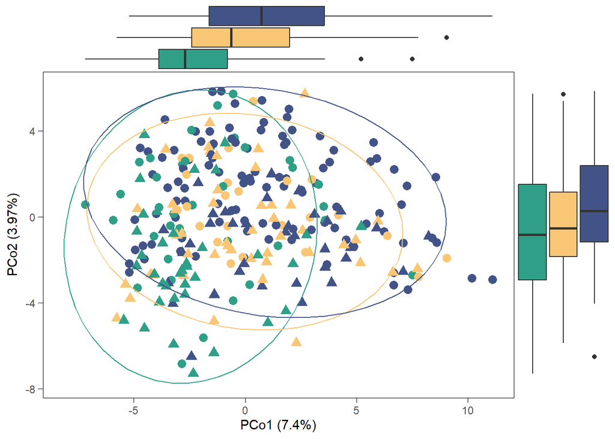

```r
p <- pca_plot_custom(filt_ileum_genus_tab,
                                 filt_ileum_genus_taxa,
                                 filt_ileum_metadata,
                                 show_boxplots = TRUE,
                                 variable = "Group", size=3, show_legend= FALSE)

# save the results
pca_plots_list[[paste(segment,level,"custom")]] <- p

# see the results
p
```

#### Saving results

```r
write.xlsx(pairwise_aitchison_raw[[paste(level, segment)]],
           file = file.path(path,
           paste0("beta_diversity_results_", segment,".xlsx")))
```

### Supplementary analysis

```r
supplements_beta <- list()
```

#### Genus level

```r
level="genus"
```

##### Bray-Curtis

**PERMANOVA**

```r
pairwise_df <- filt_ileum_genus_tab %>% column_to_rownames("SeqID") %>% t()

# main effect
pp_main <- pairwise.adonis(pairwise_df,
                           filt_ileum_metadata$Group,
                           covariate = filt_ileum_metadata$Country,
                           sim.method = "bray", p.adjust.m="BH")

# interaction
pp_int <- pairwise.adonis(pairwise_df,
                          filt_ileum_metadata$Group,
                          covariate = filt_ileum_metadata$Country,
                          interaction = TRUE, sim.method = "bray",
                          p.adjust.m="BH")

# tidy the results
pp_factor <- pp_main[[1]]
pp_cov <- pp_main[[2]]
pp_fac.cov <- pp_int[[3]]

cols <- c("pairs","Df","SumsOfSqs", "F.Model","R2","p.value", "p.adjusted", "sig")
colnames(pp_factor) <- cols; colnames(pp_cov) <- cols; colnames(pp_fac.cov) <- cols;

# save raw results
supplements_beta[[paste("bray",level,segment)]] <- rbind(pp_factor,pp_cov,pp_fac.cov)
```

```r
# see the results
knitr::kable(pp_factor,digits = 3,caption = "PERMANOVA, GROUP separation")
```

PERMANOVA, GROUP separation

| pairs | Df | SumsOfSqs | F.Model | R2 | p.value | p.adjusted | sig |
| --- | --- | --- | --- | --- | --- | --- | --- |
| pre_ltx vs healthy | 1 | 0.963 | 5.058 | 0.033 | 0.001 | 0.002 | ** |
| pre_ltx vs post_ltx | 1 | 0.342 | 1.581 | 0.007 | 0.070 | 0.070 |  |
| post_ltx vs healthy | 1 | 1.551 | 7.718 | 0.034 | 0.001 | 0.002 | ** |

```r
knitr::kable(pp_cov,digits = 3,caption = "PERMANOVA, COUNTRY separation")
```

PERMANOVA, COUNTRY separation

| pairs | Df | SumsOfSqs | F.Model | R2 | p.value | p.adjusted | sig |
| --- | --- | --- | --- | --- | --- | --- | --- |
| pre_ltx vs healthy , Country | 1 | 1.132 | 5.948 | 0.039 | 0.001 | 0.001 | *** |
| pre_ltx vs post_ltx , Country | 1 | 1.991 | 9.200 | 0.042 | 0.001 | 0.001 | *** |
| post_ltx vs healthy , Country | 1 | 1.656 | 8.242 | 0.037 | 0.001 | 0.001 | *** |

```r
knitr::kable(pp_fac.cov,digits = 3,caption = "PERMANOVA, INTERACTION GROUP:Country")
```

PERMANOVA, INTERACTION GROUP:Country

| pairs | Df | SumsOfSqs | F.Model | R2 | p.value | p.adjusted | sig |
| --- | --- | --- | --- | --- | --- | --- | --- |
| pre_ltx vs healthy : Country | 1 | 0.449 | 2.380 | 0.016 | 0.002 | 0.006 | ** |
| pre_ltx vs post_ltx : Country | 1 | 0.330 | 1.527 | 0.007 | 0.075 | 0.075 |  |
| post_ltx vs healthy : Country | 1 | 0.376 | 1.878 | 0.008 | 0.013 | 0.020 | * |

Interaction check

```r
interaction_sig <- pp_fac.cov$pairs[pp_fac.cov$p.adjusted < 0.05]

for (i in 1:length(interaction_sig)){
  group1 <- unlist(strsplit(interaction_sig[i],split = " vs "))[1]
  group2 <- unlist(strsplit(interaction_sig[i],split = " vs "))[2]
  group2 <- unlist(strsplit(group2,split = " : "))[1]

  result_list <- adonis_postanalysis(x=pairwise_df,
                      factors = filt_ileum_metadata$Group,
                      covariate = filt_ileum_metadata$Country,
                      group1 = group1,
                      group2 = group2,
                      sim.method = 'bray')
  print(result_list)
}
```

```
## $pre_ltx_healthy_CZ
## Permutation test for adonis under reduced model
## Terms added sequentially (first to last)
## Permutation: free
## Number of permutations: 999
##
## adonis2(formula = x1 ~ Fac, data = x2, permutations = perm)
##          Df SumOfSqs     R2      F Pr(>F) p.adjusted
## Fac       1   0.4144 0.0363 2.2222  0.006      0.006
## Residual 59  11.0035 0.9637
## Total    60  11.4180 1.0000
##
## $pre_ltx_healthy_NO
## Permutation test for adonis under reduced model
## Terms added sequentially (first to last)
## Permutation: free
## Number of permutations: 999
##
## adonis2(formula = x1 ~ Fac, data = x2, permutations = perm)
##          Df SumOfSqs      R2      F Pr(>F) p.adjusted
## Fac       1   0.9972 0.06156 5.2483  0.001  0.0013333
## Residual 80  15.2005 0.93844
## Total    81  16.1977 1.00000
##
## $pre_ltx_CZ_vs_NO
## Permutation test for adonis under reduced model
## Terms added sequentially (first to last)
## Permutation: free
## Number of permutations: 999
##
## adonis2(formula = x1 ~ Cov, data = x2, permutations = perm)
##          Df SumOfSqs      R2      F Pr(>F) p.adjusted
## Cov       1   0.9344 0.06093 4.4123  0.001  0.0013333
## Residual 68  14.4010 0.93907
## Total    69  15.3354 1.00000
##
## $healthy_CZ_vs_NO
## Permutation test for adonis under reduced model
## Terms added sequentially (first to last)
## Permutation: free
```

[output cut: 40 more lines]

```
## Cov        1   1.3859 0.04469 6.3619  0.001      0.001
## Residual 136  29.6263 0.95531
## Total    137  31.0121 1.00000
##
## $healthy_CZ_vs_NO
## Permutation test for adonis under reduced model
## Terms added sequentially (first to last)
## Permutation: free
## Number of permutations: 999
##
## adonis2(formula = x1 ~ Cov, data = x2, permutations = perm)
##          Df SumOfSqs      R2      F Pr(>F) p.adjusted
## Cov       1   0.6466 0.05193 3.8893  0.001      0.001
## Residual 71  11.8030 0.94807
## Total    72  12.4496 1.00000
```

**Plots**

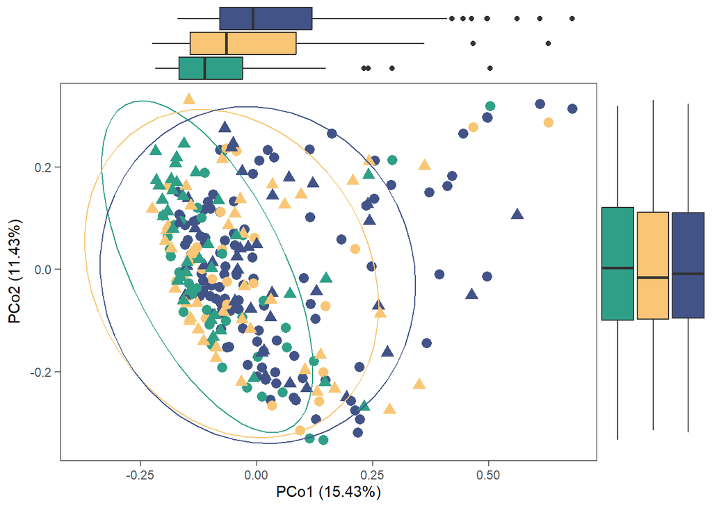

```r
p <- pca_plot_custom(filt_ileum_genus_tab,
                                 filt_ileum_genus_taxa,
                                 filt_ileum_metadata,
                                 measure = "bray",
                                 show_boxplots = TRUE,
                                 variable = "Group", size=3, show_legend= FALSE)

# save the results
supplements_beta[[paste("PCoA bray",level,segment)]] <- p

# see the results
p
```

##### Jaccard

**PERMANOVA**

```r
pairwise_df <- filt_ileum_genus_tab %>% column_to_rownames("SeqID") %>% t()

# main effect
pp_main <- pairwise.adonis(pairwise_df,
                           filt_ileum_metadata$Group,
                           covariate = filt_ileum_metadata$Country,
                           sim.method = "jaccard", p.adjust.m="BH")

# interaction
pp_int <- pairwise.adonis(pairwise_df,
                          filt_ileum_metadata$Group,
                          covariate = filt_ileum_metadata$Country,
                          interaction = TRUE, sim.method = "jaccard",
                          p.adjust.m="BH")

# tidy the results
pp_factor <- pp_main[[1]]
pp_cov <- pp_main[[2]]
pp_fac.cov <- pp_int[[3]]

cols <- c("pairs","Df","SumsOfSqs", "F.Model","R2","p.value", "p.adjusted", "sig")
colnames(pp_factor) <- cols; colnames(pp_cov) <- cols; colnames(pp_fac.cov) <- cols;

# save raw results
supplements_beta[[paste("jaccard",level,segment)]] <- rbind(pp_factor,
                                                            pp_cov,
                                                            pp_fac.cov)
```

```r
# see the results
knitr::kable(pp_factor,digits = 3,caption = "PERMANOVA, GROUP separation")
```

PERMANOVA, GROUP separation

| pairs | Df | SumsOfSqs | F.Model | R2 | p.value | p.adjusted | sig |
| --- | --- | --- | --- | --- | --- | --- | --- |
| pre_ltx vs healthy | 1 | 1.087 | 3.929 | 0.026 | 0.001 | 0.002 | ** |
| pre_ltx vs post_ltx | 1 | 0.439 | 1.457 | 0.007 | 0.045 | 0.045 | * |
| post_ltx vs healthy | 1 | 1.633 | 5.675 | 0.026 | 0.001 | 0.002 | ** |

```r
knitr::kable(pp_cov,digits = 3,caption = "PERMANOVA, COUNTRY separation")
```

PERMANOVA, COUNTRY separation

| pairs | Df | SumsOfSqs | F.Model | R2 | p.value | p.adjusted | sig |
| --- | --- | --- | --- | --- | --- | --- | --- |
| pre_ltx vs healthy , Country | 1 | 1.232 | 4.452 | 0.030 | 0.001 | 0.001 | *** |
| pre_ltx vs post_ltx , Country | 1 | 1.965 | 6.513 | 0.030 | 0.001 | 0.001 | *** |
| post_ltx vs healthy , Country | 1 | 1.751 | 6.085 | 0.028 | 0.001 | 0.001 | *** |

```r
knitr::kable(pp_fac.cov,digits = 3,caption = "PERMANOVA, INTERACTION GROUP:Country")
```

PERMANOVA, INTERACTION GROUP:Country

| pairs | Df | SumsOfSqs | F.Model | R2 | p.value | p.adjusted | sig |
| --- | --- | --- | --- | --- | --- | --- | --- |
| pre_ltx vs healthy : Country | 1 | 0.525 | 1.912 | 0.013 | 0.002 | 0.006 | ** |
| pre_ltx vs post_ltx : Country | 1 | 0.405 | 1.346 | 0.006 | 0.072 | 0.072 |  |
| post_ltx vs healthy : Country | 1 | 0.450 | 1.569 | 0.007 | 0.017 | 0.026 | * |

Interaction check

```r
interaction_sig <- pp_fac.cov$pairs[pp_fac.cov$p.adjusted < 0.05]

for (i in 1:length(interaction_sig)){
  group1 <- unlist(strsplit(interaction_sig[i],split = " vs "))[1]
  group2 <- unlist(strsplit(interaction_sig[i],split = " vs "))[2]
  group2 <- unlist(strsplit(group2,split = " : "))[1]

  result_list <- adonis_postanalysis(x=pairwise_df,
                      factors = filt_ileum_metadata$Group,
                      covariate = filt_ileum_metadata$Country,
                      group1 = group1,
                      group2 = group2,
                      sim.method = 'jaccard')
  print(result_list)
}
```

```
## $pre_ltx_healthy_CZ
## Permutation test for adonis under reduced model
## Terms added sequentially (first to last)
## Permutation: free
## Number of permutations: 999
##
## adonis2(formula = x1 ~ Fac, data = x2, permutations = perm)
##          Df SumOfSqs      R2      F Pr(>F) p.adjusted
## Fac       1   0.5009 0.03035 1.8467  0.007      0.007
## Residual 59  16.0018 0.96965
## Total    60  16.5027 1.00000
##
## $pre_ltx_healthy_NO
## Permutation test for adonis under reduced model
## Terms added sequentially (first to last)
## Permutation: free
## Number of permutations: 999
##
## adonis2(formula = x1 ~ Fac, data = x2, permutations = perm)
##          Df SumOfSqs      R2      F Pr(>F) p.adjusted
## Fac       1   1.1117 0.04768 4.0054  0.001  0.0013333
## Residual 80  22.2037 0.95232
## Total    81  23.3154 1.00000
##
## $pre_ltx_CZ_vs_NO
## Permutation test for adonis under reduced model
## Terms added sequentially (first to last)
## Permutation: free
## Number of permutations: 999
##
## adonis2(formula = x1 ~ Cov, data = x2, permutations = perm)
##          Df SumOfSqs      R2      F Pr(>F) p.adjusted
## Cov       1   0.9632 0.04568 3.2547  0.001  0.0013333
## Residual 68  20.1235 0.95432
## Total    69  21.0867 1.00000
##
## $healthy_CZ_vs_NO
## Permutation test for adonis under reduced model
## Terms added sequentially (first to last)
## Permutation: free
```

[output cut: 40 more lines]

```
## Cov        1    1.407 0.03294 4.6318  0.001      0.001
## Residual 136   41.306 0.96706
## Total    137   42.713 1.00000
##
## $healthy_CZ_vs_NO
## Permutation test for adonis under reduced model
## Terms added sequentially (first to last)
## Permutation: free
## Number of permutations: 999
##
## adonis2(formula = x1 ~ Cov, data = x2, permutations = perm)
##          Df SumOfSqs      R2      F Pr(>F) p.adjusted
## Cov       1    0.794 0.04206 3.1176  0.001      0.001
## Residual 71   18.082 0.95794
## Total    72   18.876 1.00000
```

**Plots**

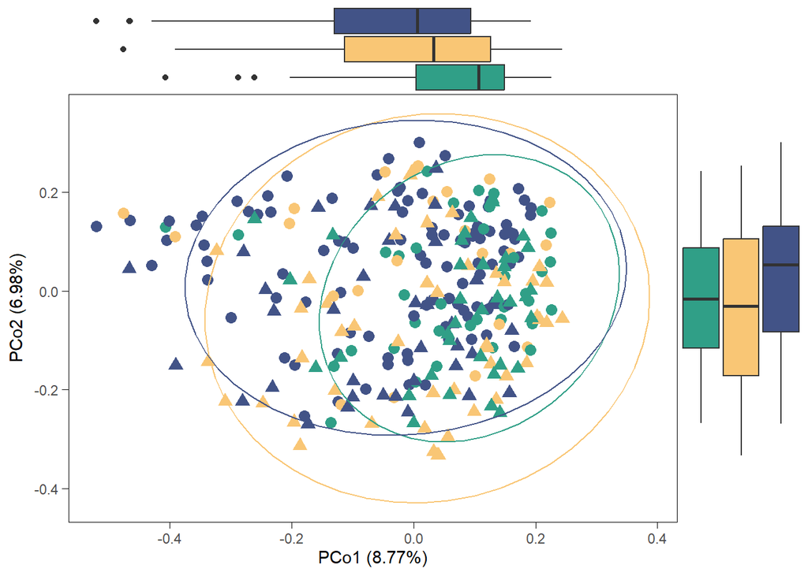

```r
p <- pca_plot_custom(filt_ileum_genus_tab,
                                 filt_ileum_genus_taxa,
                                 filt_ileum_metadata,
                                 measure = "jaccard",
                                 show_boxplots = TRUE,
                                 variable = "Group", size=3, show_legend= FALSE)

# save the results
supplements_beta[[paste("PCoA jaccard",level,segment)]] <- p

# see the results
p
```

#### ASV level

```r
level="ASV"
```

##### Aitchison

**PERMANOVA**

```r
# preparing data frame
pairwise_df <- filt_ileum_asv_tab %>% column_to_rownames("SeqID") %>% t()

# main effect
pp_main <- pairwise.adonis(pairwise_df,
                           filt_ileum_metadata$Group,
                           covariate = filt_ileum_metadata$Country,
                           sim.method = "robust.aitchison", p.adjust.m="BH")

# interaction
pp_int <- pairwise.adonis(pairwise_df,
                          filt_ileum_metadata$Group,
                          covariate = filt_ileum_metadata$Country,
                          interaction = TRUE, sim.method = "robust.aitchison",
                          p.adjust.m="BH")

pp_factor <- pp_main[[1]]
pp_cov <- pp_main[[2]]
pp_fac.cov <- pp_int[[3]]

cols <- c("pairs","Df","SumsOfSqs", "F.Model","R2","p.value", "p.adjusted", "sig")
colnames(pp_factor) <- cols; colnames(pp_cov) <- cols; colnames(pp_fac.cov) <- cols;

# save raw results
supplements_beta[[paste("aitchison",level,segment)]] <- rbind(pp_factor,
                                                            pp_cov,
                                                            pp_fac.cov)
```

```r
# see the results
knitr::kable(pp_factor,digits = 3,caption = "PERMANOVA, GROUP separation")
```

PERMANOVA, GROUP separation

| pairs | Df | SumsOfSqs | F.Model | R2 | p.value | p.adjusted | sig |
| --- | --- | --- | --- | --- | --- | --- | --- |
| pre_ltx vs healthy | 1 | 1010.000 | 3.749 | 0.026 | 0.001 | 0.002 | ** |
| pre_ltx vs post_ltx | 1 | 364.559 | 1.485 | 0.007 | 0.003 | 0.003 | ** |
| post_ltx vs healthy | 1 | 1389.311 | 5.466 | 0.025 | 0.001 | 0.002 | ** |

```r
knitr::kable(pp_cov,digits = 3,caption = "PERMANOVA, COUNTRY separation")
```

PERMANOVA, COUNTRY separation

| pairs | Df | SumsOfSqs | F.Model | R2 | p.value | p.adjusted | sig |
| --- | --- | --- | --- | --- | --- | --- | --- |
| pre_ltx vs healthy , Country | 1 | 603.397 | 2.239 | 0.015 | 0.001 | 0.001 | *** |
| pre_ltx vs post_ltx , Country | 1 | 671.339 | 2.734 | 0.013 | 0.001 | 0.001 | *** |
| post_ltx vs healthy , Country | 1 | 789.105 | 3.105 | 0.014 | 0.001 | 0.001 | *** |

```r
knitr::kable(pp_fac.cov,digits = 3,caption = "PERMANOVA, INTERACTION GROUP:Country")
```

PERMANOVA, INTERACTION GROUP:Country

| pairs | Df | SumsOfSqs | F.Model | R2 | p.value | p.adjusted | sig |
| --- | --- | --- | --- | --- | --- | --- | --- |
| pre_ltx vs healthy : Country | 1 | 364.013 | 1.354 | 0.009 | 0.014 | 0.021 | * |
| pre_ltx vs post_ltx : Country | 1 | 352.491 | 1.439 | 0.007 | 0.007 | 0.021 | * |
| post_ltx vs healthy : Country | 1 | 281.750 | 1.109 | 0.005 | 0.170 | 0.170 |  |

Interaction check

```r
interaction_sig <- pp_fac.cov$pairs[pp_fac.cov$p.adjusted < 0.05]

for (i in 1:length(interaction_sig)){
  group1 <- unlist(strsplit(interaction_sig[i],split = " vs "))[1]
  group2 <- unlist(strsplit(interaction_sig[i],split = " vs "))[2]
  group2 <- unlist(strsplit(group2,split = " : "))[1]

  result_list <- adonis_postanalysis(x=pairwise_df,
                      factors = filt_ileum_metadata$Group,
                      covariate = filt_ileum_metadata$Country,
                      group1 = group1,
                      group2 = group2)
  print(result_list)
}
```

```
## $pre_ltx_healthy_CZ
## Permutation test for adonis under reduced model
## Terms added sequentially (first to last)
## Permutation: free
## Number of permutations: 999
##
## adonis2(formula = x1 ~ Fac, data = x2, permutations = perm)
##          Df SumOfSqs      R2      F Pr(>F) p.adjusted
## Fac       1      420 0.02629 1.5929  0.004      0.004
## Residual 59    15557 0.97371
## Total    60    15977 1.00000
##
## $pre_ltx_healthy_NO
## Permutation test for adonis under reduced model
## Terms added sequentially (first to last)
## Permutation: free
## Number of permutations: 999
##
## adonis2(formula = x1 ~ Fac, data = x2, permutations = perm)
##          Df SumOfSqs      R2      F Pr(>F) p.adjusted
## Fac       1      954 0.04193 3.5009  0.001      0.002
## Residual 80    21800 0.95807
## Total    81    22754 1.00000
##
## $pre_ltx_CZ_vs_NO
## Permutation test for adonis under reduced model
## Terms added sequentially (first to last)
## Permutation: free
## Number of permutations: 999
##
## adonis2(formula = x1 ~ Cov, data = x2, permutations = perm)
##          Df SumOfSqs      R2      F Pr(>F) p.adjusted
## Cov       1    460.2 0.02579 1.8004  0.002  0.0026667
## Residual 68  17380.9 0.97421
## Total    69  17841.1 1.00000
##
## $healthy_CZ_vs_NO
## Permutation test for adonis under reduced model
## Terms added sequentially (first to last)
## Permutation: free
```

[output cut: 40 more lines]

```
## Cov       1    460.2 0.02579 1.8004  0.002  0.0026667
## Residual 68  17380.9 0.97421
## Total    69  17841.1 1.00000
##
## $post_ltx_CZ_vs_NO
## Permutation test for adonis under reduced model
## Terms added sequentially (first to last)
## Permutation: free
## Number of permutations: 999
##
## adonis2(formula = x1 ~ Cov, data = x2, permutations = perm)
##           Df SumOfSqs      R2      F Pr(>F) p.adjusted
## Cov        1      564 0.01699 2.3509  0.001      0.002
## Residual 136    32607 0.98301
## Total    137    33170 1.00000
```

**PCoA**

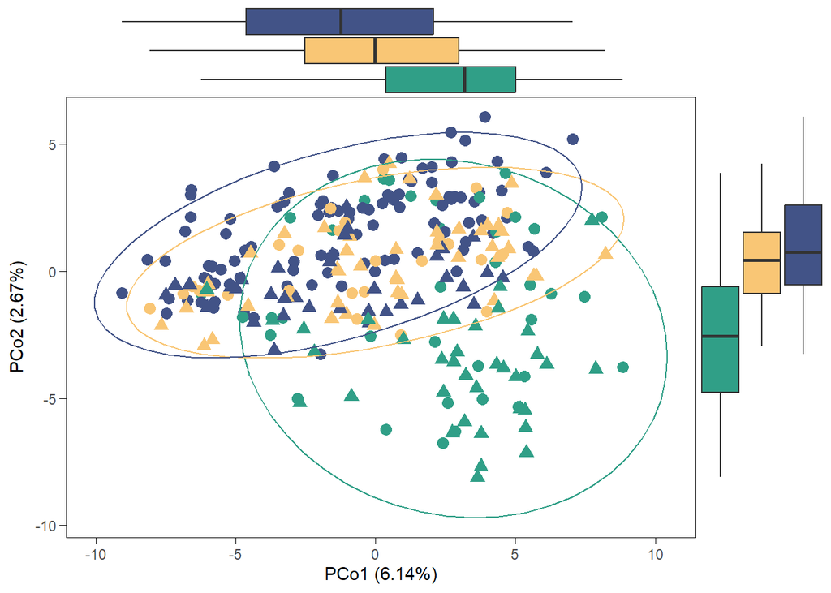

```r
p <- pca_plot_custom(filt_ileum_asv_tab,
                           filt_ileum_taxa_tab,
                           filt_ileum_metadata,
                           show_boxplots = TRUE,
                           variable = "Group", size=3, show_legend= FALSE)

# save the results
supplements_beta[[paste("PCoA aitchison",level,segment)]] <- p

# see the results
p
```

##### Bray-Curtis

**PERMANOVA**

```r
# preparing data frame
pairwise_df <- filt_ileum_asv_tab %>% column_to_rownames("SeqID") %>% t()

# main effect
pp_main <- pairwise.adonis(pairwise_df,
                           filt_ileum_metadata$Group,
                           covariate = filt_ileum_metadata$Country,
                           sim.method = "bray", p.adjust.m="BH")

# interaction
pp_int <- pairwise.adonis(pairwise_df,
                          filt_ileum_metadata$Group,
                          covariate = filt_ileum_metadata$Country,
                          interaction = TRUE, sim.method = "bray", p.adjust.m="BH")

pp_factor <- pp_main[[1]]
pp_cov <- pp_main[[2]]
pp_fac.cov <- pp_int[[3]]

cols <- c("pairs","Df","SumsOfSqs", "F.Model","R2","p.value", "p.adjusted", "sig")
colnames(pp_factor) <- cols; colnames(pp_cov) <- cols; colnames(pp_fac.cov) <- cols;

# save raw results
supplements_beta[[paste("bray",level,segment)]] <- rbind(pp_factor,
                                                            pp_cov,
                                                            pp_fac.cov)
```

```r
# see the results
knitr::kable(pp_factor,digits = 3,caption = "PERMANOVA, GROUP separation")
```

PERMANOVA, GROUP separation

| pairs | Df | SumsOfSqs | F.Model | R2 | p.value | p.adjusted | sig |
| --- | --- | --- | --- | --- | --- | --- | --- |
| pre_ltx vs healthy | 1 | 1.628 | 5.225 | 0.035 | 0.001 | 0.002 | ** |
| pre_ltx vs post_ltx | 1 | 0.519 | 1.563 | 0.007 | 0.024 | 0.024 | * |
| post_ltx vs healthy | 1 | 2.428 | 7.667 | 0.035 | 0.001 | 0.002 | ** |

```r
knitr::kable(pp_cov,digits = 3,caption = "PERMANOVA, COUNTRY separation")
```

PERMANOVA, COUNTRY separation

| pairs | Df | SumsOfSqs | F.Model | R2 | p.value | p.adjusted | sig |
| --- | --- | --- | --- | --- | --- | --- | --- |
| pre_ltx vs healthy , Country | 1 | 1.136 | 3.644 | 0.024 | 0.001 | 0.001 | *** |
| pre_ltx vs post_ltx , Country | 1 | 1.676 | 5.049 | 0.024 | 0.001 | 0.001 | *** |
| post_ltx vs healthy , Country | 1 | 1.667 | 5.264 | 0.024 | 0.001 | 0.001 | *** |

```r
knitr::kable(pp_fac.cov,digits = 3,caption = "PERMANOVA, INTERACTION GROUP:Country")
```

PERMANOVA, INTERACTION GROUP:Country

| pairs | Df | SumsOfSqs | F.Model | R2 | p.value | p.adjusted | sig |
| --- | --- | --- | --- | --- | --- | --- | --- |
| pre_ltx vs healthy : Country | 1 | 0.469 | 1.511 | 0.010 | 0.027 | 0.040 | * |
| pre_ltx vs post_ltx : Country | 1 | 0.562 | 1.698 | 0.008 | 0.010 | 0.030 | * |
| post_ltx vs healthy : Country | 1 | 0.432 | 1.367 | 0.006 | 0.064 | 0.064 |  |

Interaction check

```r
interaction_sig <- pp_fac.cov$pairs[pp_fac.cov$p.adjusted < 0.05]

for (i in 1:length(interaction_sig)){
  group1 <- unlist(strsplit(interaction_sig[i],split = " vs "))[1]
  group2 <- unlist(strsplit(interaction_sig[i],split = " vs "))[2]
  group2 <- unlist(strsplit(group2,split = " : "))[1]

  result_list <- adonis_postanalysis(x=pairwise_df,
                      factors = filt_ileum_metadata$Group,
                      covariate = filt_ileum_metadata$Country,
                      group1 = group1,
                      group2 = group2,
                      sim.method = 'bray')
  print(result_list)
}
```

```
## $pre_ltx_healthy_CZ
## Permutation test for adonis under reduced model
## Terms added sequentially (first to last)
## Permutation: free
## Number of permutations: 999
##
## adonis2(formula = x1 ~ Fac, data = x2, permutations = perm)
##          Df SumOfSqs      R2      F Pr(>F) p.adjusted
## Fac       1   0.5756 0.02993 1.8204  0.005      0.005
## Residual 59  18.6557 0.97007
## Total    60  19.2313 1.00000
##
## $pre_ltx_healthy_NO
## Permutation test for adonis under reduced model
## Terms added sequentially (first to last)
## Permutation: free
## Number of permutations: 999
##
## adonis2(formula = x1 ~ Fac, data = x2, permutations = perm)
##          Df SumOfSqs      R2     F Pr(>F) p.adjusted
## Fac       1   1.5215 0.05848 4.969  0.001  0.0013333
## Residual 80  24.4953 0.94152
## Total    81  26.0168 1.00000
##
## $pre_ltx_CZ_vs_NO
## Permutation test for adonis under reduced model
## Terms added sequentially (first to last)
## Permutation: free
## Number of permutations: 999
##
## adonis2(formula = x1 ~ Cov, data = x2, permutations = perm)
##          Df SumOfSqs      R2      F Pr(>F) p.adjusted
## Cov       1   0.8717 0.03713 2.6224  0.001  0.0013333
## Residual 68  22.6028 0.96287
## Total    69  23.4744 1.00000
##
## $healthy_CZ_vs_NO
## Permutation test for adonis under reduced model
## Terms added sequentially (first to last)
## Permutation: free
```

[output cut: 40 more lines]

```
## Cov       1   0.8717 0.03713 2.6224  0.001      0.002
## Residual 68  22.6028 0.96287
## Total    69  23.4744 1.00000
##
## $post_ltx_CZ_vs_NO
## Permutation test for adonis under reduced model
## Terms added sequentially (first to last)
## Permutation: free
## Number of permutations: 999
##
## adonis2(formula = x1 ~ Cov, data = x2, permutations = perm)
##           Df SumOfSqs      R2      F Pr(>F) p.adjusted
## Cov        1    1.366 0.02953 4.1389  0.001      0.002
## Residual 136   44.897 0.97047
## Total    137   46.263 1.00000
```

**PCoA**

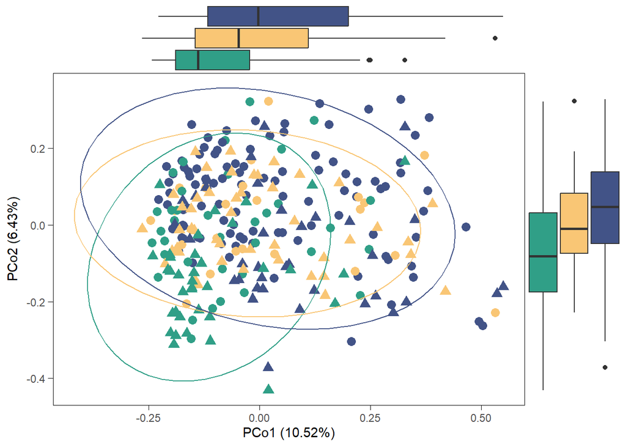

```r
p <- pca_plot_custom(filt_ileum_asv_tab,
                     filt_ileum_taxa_tab,
                     filt_ileum_metadata,
                     measure = "bray",
                     show_boxplots = TRUE,
                     variable = "Group", size=3, show_legend= FALSE)

# save the results
supplements_beta[[paste("PCoA bray",level,segment)]] <- p

# see the results
p
```

##### Jaccard

**PERMANOVA**

```r
# preparing data frame
pairwise_df <- filt_ileum_asv_tab %>% column_to_rownames("SeqID") %>% t()

# main effect
pp_main <- pairwise.adonis(pairwise_df,
                           filt_ileum_metadata$Group,
                           covariate = filt_ileum_metadata$Country,
                           sim.method = "jaccard", p.adjust.m="BH")

# interaction
pp_int <- pairwise.adonis(pairwise_df,
                          filt_ileum_metadata$Group,
                          covariate = filt_ileum_metadata$Country,
                          interaction = TRUE, sim.method = "jaccard",
                          p.adjust.m="BH")

pp_factor <- pp_main[[1]]
pp_cov <- pp_main[[2]]
pp_fac.cov <- pp_int[[3]]

cols <- c("pairs","Df","SumsOfSqs", "F.Model","R2","p.value", "p.adjusted", "sig")
colnames(pp_factor) <- cols; colnames(pp_cov) <- cols; colnames(pp_fac.cov) <- cols;

# save raw results
supplements_beta[[paste("jaccard",level,segment)]] <- rbind(pp_factor,
                                                            pp_cov,
                                                            pp_fac.cov)
```

```r
# see the results
knitr::kable(pp_factor,digits = 3,caption = "PERMANOVA, GROUP separation")
```

PERMANOVA, GROUP separation

| pairs | Df | SumsOfSqs | F.Model | R2 | p.value | p.adjusted | sig |
| --- | --- | --- | --- | --- | --- | --- | --- |
| pre_ltx vs healthy | 1 | 1.354 | 3.531 | 0.024 | 0.001 | 0.002 | ** |
| pre_ltx vs post_ltx | 1 | 0.528 | 1.327 | 0.006 | 0.024 | 0.024 | * |
| post_ltx vs healthy | 1 | 1.921 | 4.964 | 0.023 | 0.001 | 0.002 | ** |

```r
knitr::kable(pp_cov,digits = 3,caption = "PERMANOVA, COUNTRY separation")
```

PERMANOVA, COUNTRY separation

| pairs | Df | SumsOfSqs | F.Model | R2 | p.value | p.adjusted | sig |
| --- | --- | --- | --- | --- | --- | --- | --- |
| pre_ltx vs healthy , Country | 1 | 0.994 | 2.593 | 0.018 | 0.001 | 0.001 | *** |
| pre_ltx vs post_ltx , Country | 1 | 1.384 | 3.480 | 0.017 | 0.001 | 0.001 | *** |
| post_ltx vs healthy , Country | 1 | 1.396 | 3.607 | 0.017 | 0.001 | 0.001 | *** |

```r
knitr::kable(pp_fac.cov,digits = 3,caption = "PERMANOVA, INTERACTION GROUP:Country")
```

PERMANOVA, INTERACTION GROUP:Country

| pairs | Df | SumsOfSqs | F.Model | R2 | p.value | p.adjusted | sig |
| --- | --- | --- | --- | --- | --- | --- | --- |
| pre_ltx vs healthy : Country | 1 | 0.514 | 1.344 | 0.009 | 0.020 | 0.030 | * |
| pre_ltx vs post_ltx : Country | 1 | 0.571 | 1.439 | 0.007 | 0.010 | 0.030 | * |
| post_ltx vs healthy : Country | 1 | 0.488 | 1.262 | 0.006 | 0.041 | 0.041 | * |

Interaction check

```r
interaction_sig <- pp_fac.cov$pairs[pp_fac.cov$p.adjusted < 0.05]

for (i in 1:length(interaction_sig)){
  group1 <- unlist(strsplit(interaction_sig[i],split = " vs "))[1]
  group2 <- unlist(strsplit(interaction_sig[i],split = " vs "))[2]
  group2 <- unlist(strsplit(group2,split = " : "))[1]

  result_list <- adonis_postanalysis(x=pairwise_df,
                      factors = filt_ileum_metadata$Group,
                      covariate = filt_ileum_metadata$Country,
                      group1 = group1,
                      group2 = group2,
                      sim.method = 'jaccard')
  print(result_list)
}
```

```
## $pre_ltx_healthy_CZ
## Permutation test for adonis under reduced model
## Terms added sequentially (first to last)
## Permutation: free
## Number of permutations: 999
##
## adonis2(formula = x1 ~ Fac, data = x2, permutations = perm)
##          Df SumOfSqs      R2      F Pr(>F) p.adjusted
## Fac       1   0.5659 0.02422 1.4643  0.006      0.006
## Residual 59  22.8020 0.97578
## Total    60  23.3680 1.00000
##
## $pre_ltx_healthy_NO
## Permutation test for adonis under reduced model
## Terms added sequentially (first to last)
## Permutation: free
## Number of permutations: 999
##
## adonis2(formula = x1 ~ Fac, data = x2, permutations = perm)
##          Df SumOfSqs      R2      F Pr(>F) p.adjusted
## Fac       1    1.302 0.04112 3.4309  0.001  0.0013333
## Residual 80   30.352 0.95888
## Total    81   31.654 1.00000
##
## $pre_ltx_CZ_vs_NO
## Permutation test for adonis under reduced model
## Terms added sequentially (first to last)
## Permutation: free
## Number of permutations: 999
##
## adonis2(formula = x1 ~ Cov, data = x2, permutations = perm)
##          Df SumOfSqs      R2     F Pr(>F) p.adjusted
## Cov       1   0.7898 0.02836 1.985  0.001  0.0013333
## Residual 68  27.0550 0.97164
## Total    69  27.8447 1.00000
##
## $healthy_CZ_vs_NO
## Permutation test for adonis under reduced model
## Terms added sequentially (first to last)
## Permutation: free
```

[output cut: 88 more lines]

```
## Cov        1    1.165 0.02116 2.9397  0.001      0.001
## Residual 136   53.904 0.97884
## Total    137   55.069 1.00000
##
## $healthy_CZ_vs_NO
## Permutation test for adonis under reduced model
## Terms added sequentially (first to last)
## Permutation: free
## Number of permutations: 999
##
## adonis2(formula = x1 ~ Cov, data = x2, permutations = perm)
##          Df SumOfSqs      R2      F Pr(>F) p.adjusted
## Cov       1   0.7183 0.02679 1.9541  0.001      0.001
## Residual 71  26.0995 0.97321
## Total    72  26.8178 1.00000
```

**PCoA**

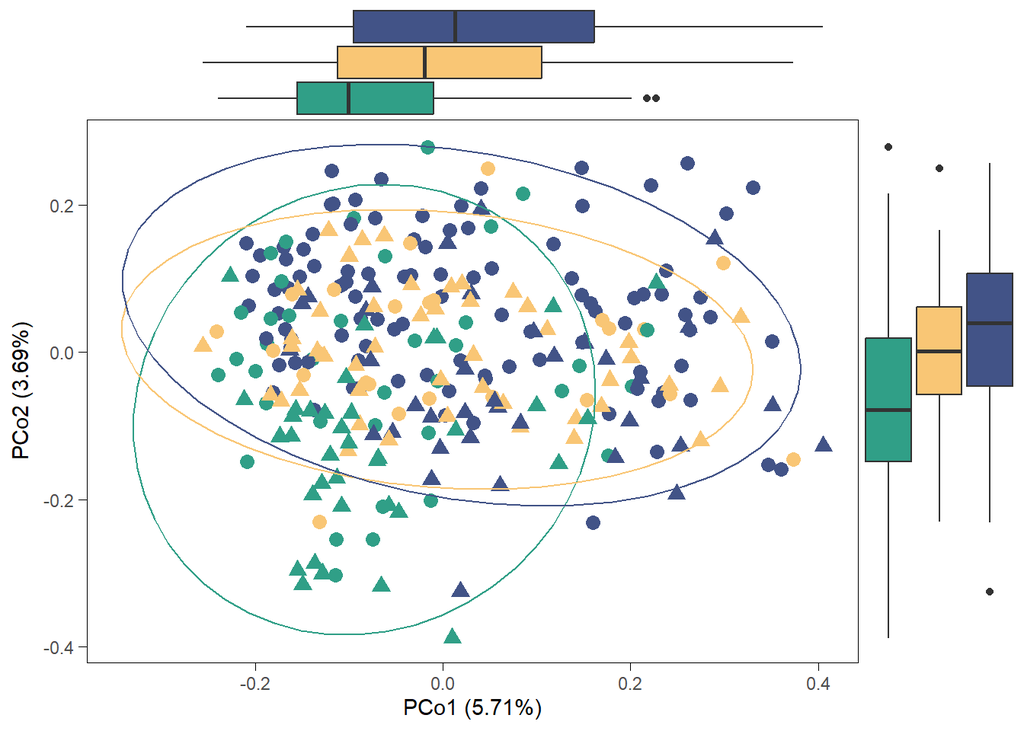

```r
p <- pca_plot_custom(filt_ileum_asv_tab,
                     filt_ileum_taxa_tab,
                     filt_ileum_metadata,
                     measure = "jaccard",
                     show_boxplots = TRUE,
                     variable = "Group", size=3, show_legend= FALSE)

# save the results
supplements_beta[[paste("PCoA jaccard",level,segment)]] <- p

# see the results
p
```

#### Saving results

```r
write.xlsx(supplements_beta[!grepl("PCoA",names(supplements_beta))],
           file = file.path(path,
           paste0("supplements_beta_diversity_", segment,".xlsx")))
```

## Univariate Analysis

Using two DAA tools - linDA and Maaslin. Only the intersection of sets selected by each tool was shown to minimize false positives. Taxa with a significant interaction effect were excluded based on individual post-hoc analysis of the Czech and Norwegian cohorts. Only taxa with significant log fold change that showed the same change direction in both countries were retained.

Main analysis is performed at genus level. In supplements, analysis is performed at ASV and phylum levels.

### Main analysis

```r
level="genus"

# needed paths
path = "../results/Q1/univariate_analysis"
path_maaslin=file.path("../intermediate_files/maaslin/Q1",level)
```

```r
# variables
raw_linda_results_genus <- list();
raw_linda_results_genus[[segment]] <- list()
linda_results_genus <- list();
linda_results_genus[[segment]] <- list()

# country and interaction problems
list_country_union <- list()
list_intersections <- list()
list_venns <- list()
uni_statistics <- list()

# workbook for final df
wb <- createWorkbook()

# PSC effect
psc_effect <- list()
```

Aggregate taxa

```r
genus_data <- aggregate_taxa(ileum_asv_tab,
                             ileum_taxa_tab,
                             taxonomic_level = level)

ileum_genus_tab <- genus_data[[1]]
ileum_genus_taxa_tab <- genus_data[[2]]

ileum_genus_asv_taxa_tab <- create_asv_taxa_table(ileum_genus_tab,
                                                  ileum_genus_taxa_tab)
```

#### pre_ltx vs healthy

We can assume, that the differentially abundant taxa between these two groups are caused by PSC disease and other factors, like liver cirrhosis and overall bad clinical condition.

```r
group <- c("healthy","pre_ltx")
comparison_name <- paste0(group[1], " vs ",group[2])
```

##### linDA

```r
# prepare the data
linda_data <- binomial_prep(ileum_genus_tab,
                            ileum_genus_taxa_tab,
                            ileum_metadata,
                            group, usage="linDA")
```

```
## Removing 84 ASV(s)
```

```
## Removing 10 ASV(s)
```

```r
filt_ileum_uni_data <- linda_data[[1]]
filt_ileum_uni_taxa <- linda_data[[2]]
filt_ileum_uni_metadata <- linda_data[[3]]

# fit the model
linda.obj <- linda(filt_ileum_uni_data,
                   filt_ileum_uni_metadata,
                   formula = '~ Group * Country')
```

```
## 0  features are filtered!
## The filtered data has  143  samples and  184  features will be tested!
## Imputation approach is used.
## Fit linear models ...
## Completed.
```

```r
linda.output <- linda.obj$output
linda.output <- linda_renaming(linda.output, group)

# save the results
group1 <- paste0(group[1], " vs ","Group",group[2])
group2 <- paste0(group[1], " , ",group[2], " - CZ vs NO")
group3 <- paste0(group[1], " vs ","Group",group[2], ":CountryNO")

for (grp in c(group1,group2,group3)){
  raw_linda_results_genus[[segment]][[grp]] <-
    rawlinda.df(linda.output,
                grp,
                filt_ileum_uni_data,
                filt_ileum_uni_taxa)

  linda_results_genus[[segment]][[grp]] <-
    linda.df(linda.output,
             grp,
             filt_ileum_uni_data,
             filt_ileum_uni_taxa)
}
```

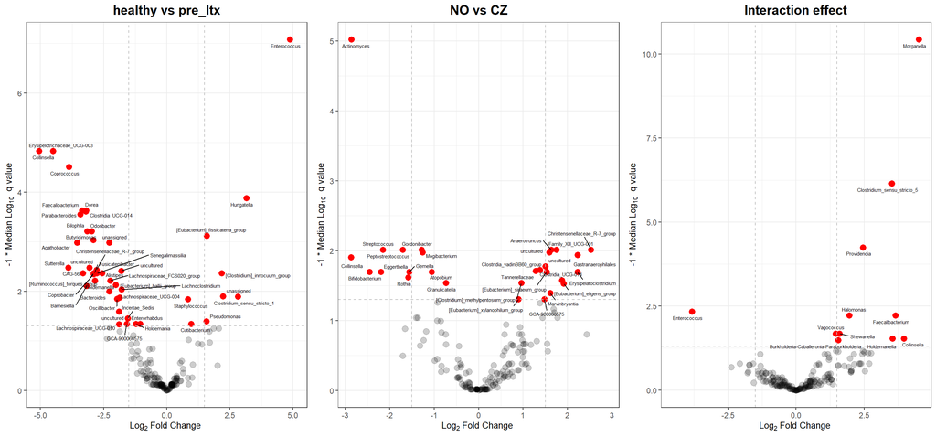

```r
# volcano plots
volcano_1 <- volcano_plot_linda(linda.output,
                                group1,
                                taxa_table = filt_ileum_uni_taxa) +
            ggtitle(comparison_title)

volcano_2  <- volcano_plot_linda(linda.output, group2,
                                taxa_table = filt_ileum_uni_taxa) +
            ggtitle("NO vs CZ")

volcano_3 <- volcano_plot_linda(linda.output, group3,
                                taxa_table = filt_ileum_uni_taxa) +
            ggtitle("Interaction effect")

volcano <- ggarrange(volcano_1,volcano_2,volcano_3, ncol=3)
volcano
```

##### MaAsLin2

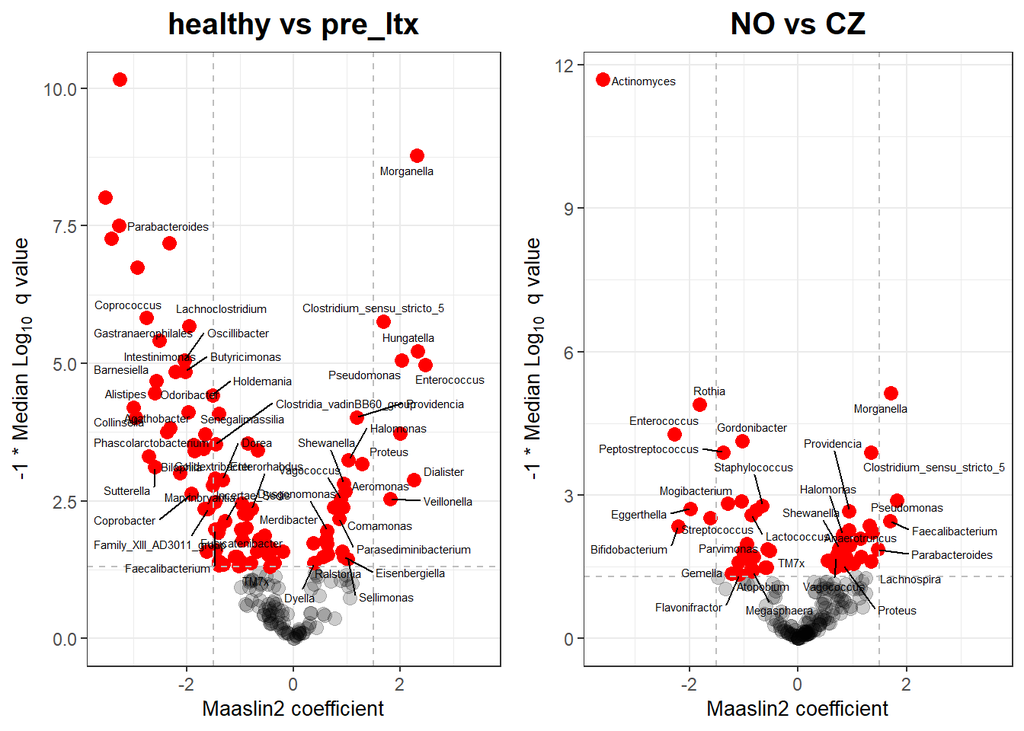

```r
volcano1 <- volcano_plot_maaslin(fit_data,filt_ileum_uni_taxa) +
            ggtitle(comparison_title)

volcano2 <- volcano_plot_maaslin(fit_data,filt_ileum_uni_taxa,variable="Country") +
            ggtitle("NO vs CZ")

volcano <- ggarrange(volcano1,volcano2, ncol=2)
volcano
```

##### Group - Intersection

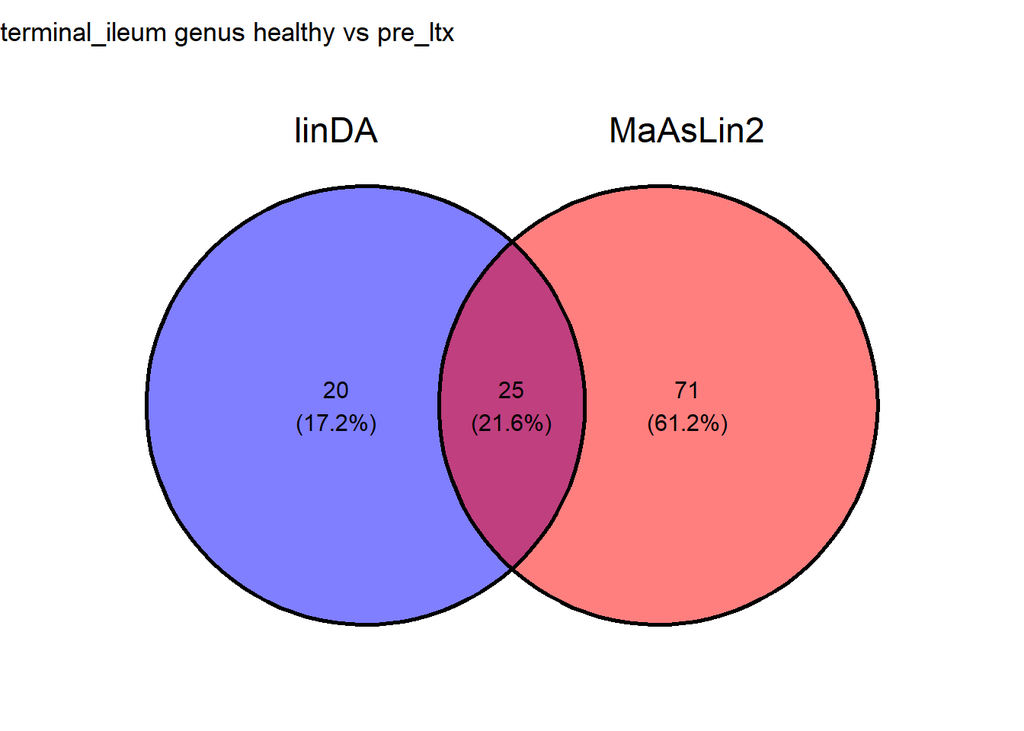

```r
intersection_results <- group_intersection(group, list_intersections, list_venns,
                                           linda.output, fit_data,
                                           raw_linda_results_genus,
                                           segment = segment,
                                           level=level)

list_intersections <- intersection_results[[1]]
list_venns <- intersection_results[[2]]
venn <- intersection_results[[3]]

# show the results
venn
```

##### Interaction effect

```r
list_interaction_significant <- country_interaction(group,
                                                    linda.output,
                                                    list_intersections,
                                          filt_ileum_uni_data,
                                          filt_ileum_uni_metadata,
                                          segment=segment,
                                          level=level)

# see the result
## significant interaction effect
list_interaction_significant[[1]]
```

```r
## results for czech cohort
list_interaction_significant[[2]]
```

```
## [1] NA
```

```r
## results for norwegian cohort
list_interaction_significant[[3]]
```

```
## [1] NA
```

Removing problematic taxa

```r
list_intersections <- removing_interaction_problems(group,
                                                    list_interaction_significant,
                                                    list_intersections,
                                                    segment=segment,
                                                    level=level)
```

##### Basic statistics

```r
uni_df <-  merge(basic_univariate_statistics(linda_data,group),
                 raw_linda_results_genus[[segment]][[group1]],
                 by="SeqID",all=TRUE)
```

```
## [1] "healthy"
## [1] "pre_ltx"
## [1] "healthy"
## [1] "pre_ltx"
```

```r
uni_df[["final_sig"]] <- uni_df$SeqID %in% list_intersections[[paste(segment,level,comparison_name)]][["SeqID"]]
uni_statistics[[segment]][[paste(level,comparison_name)]] <- uni_df

# for comparison
new_name <- comparison_name
addWorksheet(wb, sheetName = new_name)
writeData(wb, sheet = new_name, uni_df, rowNames=FALSE)
```

#### pre_ltx vs post_ltx

```r
group <- c("pre_ltx","post_ltx")
comparison_name <- paste0(group[1], " vs ",group[2])
```

##### linDA

```r
# prepare the data
linda_data <- binomial_prep(ileum_genus_tab,
                            ileum_genus_taxa_tab,
                            ileum_metadata,
                            group, usage="linDA")
```

```
## Removing 46 ASV(s)
```

```
## Removing 6 ASV(s)
```

```r
filt_ileum_uni_data <- linda_data[[1]]
filt_ileum_uni_taxa <- linda_data[[2]]
filt_ileum_uni_metadata <- linda_data[[3]]

# fit the model
linda.obj <- linda(filt_ileum_uni_data,
                   filt_ileum_uni_metadata,
                   formula = '~ Group * Country')
```

```
## 0  features are filtered!
## The filtered data has  208  samples and  172  features will be tested!
## Imputation approach is used.
## Fit linear models ...
## Completed.
```

```r
linda.output <- linda.obj$output
linda.output <- linda_renaming(linda.output, group)

# save the results
group1 <- paste0(group[1], " vs ","Group",group[2])
group2 <- paste0(group[1], " , ",group[2], " - CZ vs NO")
group3 <- paste0(group[1], " vs ","Group",group[2], ":CountryNO")

for (grp in c(group1,group2,group3)){
  raw_linda_results_genus[[segment]][[grp]] <-
    rawlinda.df(linda.output,
                grp,
                filt_ileum_uni_data,
                filt_ileum_uni_taxa)

  linda_results_genus[[segment]][[grp]] <-
    linda.df(linda.output,
             grp,
             filt_ileum_uni_data,
             filt_ileum_uni_taxa)
}
```

```r
# volcano plot
volcano_1 <- volcano_plot_linda(linda.output,
                                group1,
                                taxa_table = filt_ileum_uni_taxa) +
            ggtitle(comparison_title)

volcano_2  <- volcano_plot_linda(linda.output, group2,
                                taxa_table = filt_ileum_uni_taxa) +
            ggtitle("NO vs CZ")

volcano_3 <- volcano_plot_linda(linda.output, group3,
                                taxa_table = filt_ileum_uni_taxa) +
            ggtitle("Interaction effect")

volcano <- ggarrange(volcano_1,volcano_2,volcano_3, ncol=3)
```

##### MaAsLin2

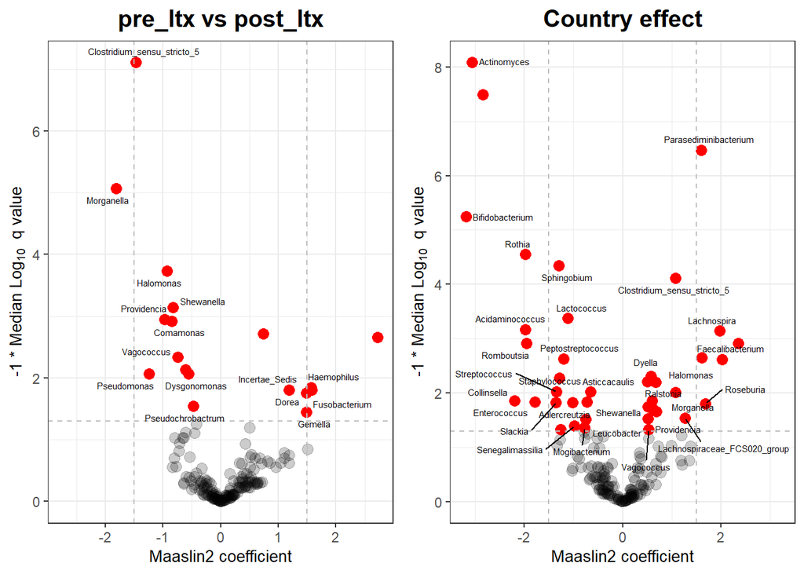

```r
volcano1 <- volcano_plot_maaslin(fit_data,filt_ileum_uni_taxa) +
            ggtitle(comparison_title)

volcano2 <- volcano_plot_maaslin(fit_data,filt_ileum_uni_taxa,variable="Country") +
            ggtitle("Country effect")

volcano <- ggarrange(volcano1,volcano2, ncol=2)
volcano
```

##### Group - Intersection

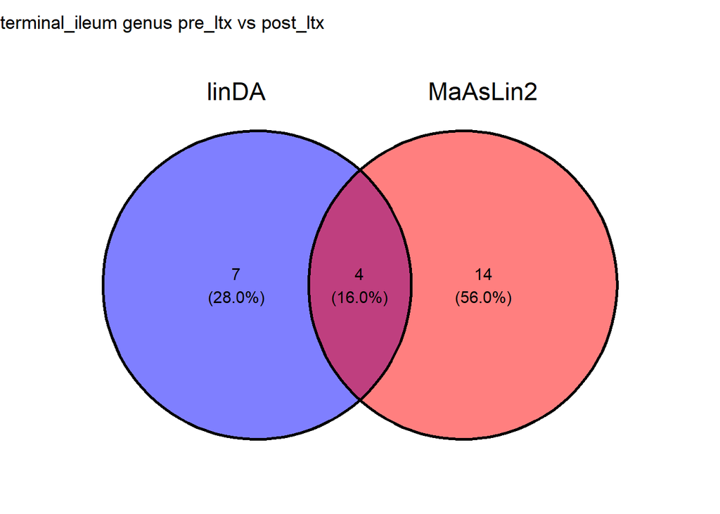

```r
intersection_results <- group_intersection(group, list_intersections, list_venns,
                                           linda.output, fit_data,
                                           raw_linda_results_genus,
                                           segment = segment,
                                           level=level)

list_intersections <- intersection_results[[1]]
list_venns <- intersection_results[[2]]
venn <- intersection_results[[3]]

# show the results
venn
```

##### Interaction effect

```r
list_interaction_significant <- country_interaction(group,
                                                    linda.output,
                                                    list_intersections,
                                          filt_ileum_uni_data,
                                          filt_ileum_uni_metadata,
                                          segment=segment,
                                          level=level)

# see the result
## significant interaction effect
list_interaction_significant[[1]]
```

```r
## results for czech cohort
list_interaction_significant[[2]]
```

```
## [1] NA
```

```r
## results for norwegian cohort
list_interaction_significant[[3]]
```

```
## [1] NA
```

Removing problematic taxa

```r
list_intersections <- removing_interaction_problems(group,
                                                    list_interaction_significant,
                                                    list_intersections,
                                                    segment=segment,
                                                    level=level)
```

##### Basic statistics

```r
uni_df <-  merge(basic_univariate_statistics(linda_data,group),
                 raw_linda_results_genus[[segment]][[group1]],
                 by="SeqID",all=TRUE)
```

```
## [1] "pre_ltx"
## [1] "post_ltx"
## [1] "pre_ltx"
## [1] "post_ltx"
```

```r
uni_df[["final_sig"]] <- uni_df$SeqID %in% list_intersections[[paste(segment,level,comparison_name)]][["SeqID"]]
uni_statistics[[segment]][[paste(level,comparison_name)]] <- uni_df

# for comparison
new_name <- comparison_name
addWorksheet(wb, sheetName = new_name)
writeData(wb, sheet = new_name, uni_df, rowNames=FALSE)
```

#### post_ltx vs healthy

We can assume, that the differentially abundant taxa between these two groups remain because of the persistent gut MB alteration due to the PSC disease. Also, transplantation itself could add to this difference, as it has definitely strong impact on microbial composition.

```r
group <- c("healthy","post_ltx")
comparison_name <- paste0(group[1], " vs ",group[2])
```

##### linDA

```r
# prepare the data
linda_data <- binomial_prep(ileum_genus_tab,
                            ileum_genus_taxa_tab,
                            ileum_metadata,
                            group, usage="linDA")
```

```
## Removing 45 ASV(s)
```

```
## Removing 2 ASV(s)
```

```r
filt_ileum_uni_data <- linda_data[[1]]
filt_ileum_uni_taxa <- linda_data[[2]]
filt_ileum_uni_metadata <- linda_data[[3]]

# fit the model
linda.obj <- linda(filt_ileum_uni_data,
                   filt_ileum_uni_metadata,
                   formula = '~ Group * Country')
```

```
## 0  features are filtered!
## The filtered data has  211  samples and  180  features will be tested!
## Imputation approach is used.
## Fit linear models ...
## Completed.
```

```r
linda.output <- linda.obj$output
linda.output <- linda_renaming(linda.output, group)

# save the results
group1 <- paste0(group[1], " vs ","Group",group[2])
group2 <- paste0(group[1], " , ",group[2], " - CZ vs NO")
group3 <- paste0(group[1], " vs ","Group",group[2], ":CountryNO")

for (grp in c(group1,group2,group3)){
  raw_linda_results_genus[[segment]][[grp]] <-
    rawlinda.df(linda.output,
                grp,
                filt_ileum_uni_data,
                filt_ileum_uni_taxa)

  linda_results_genus[[segment]][[grp]] <-
    linda.df(linda.output,
             grp,
             filt_ileum_uni_data,
             filt_ileum_uni_taxa)
}
```

```r
# volcano plot
volcano_1 <- volcano_plot_linda(linda.output,
                                group1,
                                taxa_table = filt_ileum_uni_taxa) +
            ggtitle(comparison_title)

volcano_2  <- volcano_plot_linda(linda.output, group2,
                                taxa_table = filt_ileum_uni_taxa) +
            ggtitle("NO vs CZ")

volcano_3 <- volcano_plot_linda(linda.output, group3,
                                taxa_table = filt_ileum_uni_taxa) +
            ggtitle("Interaction effect")

volcano <- ggarrange(volcano_1,volcano_2,volcano_3, ncol=3)
```

##### MaAsLin2

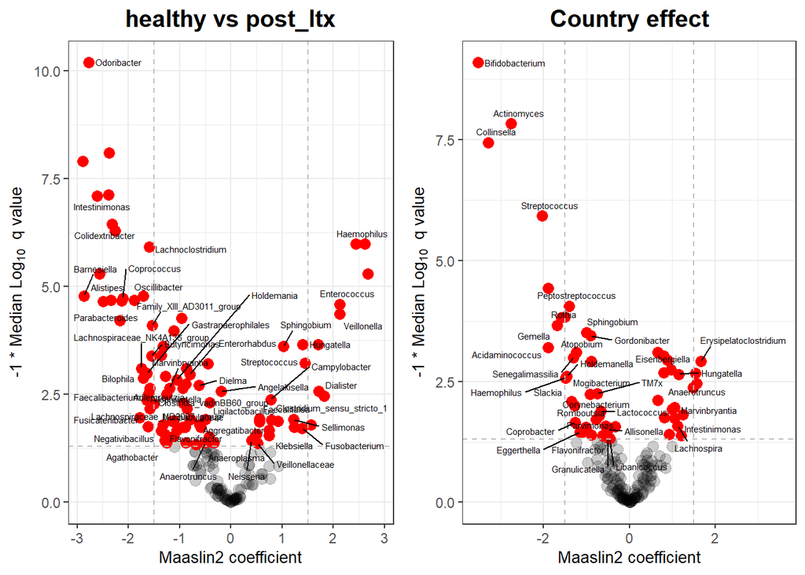

```r
volcano1 <- volcano_plot_maaslin(fit_data,filt_ileum_uni_taxa) +
            ggtitle(comparison_title)

volcano2 <- volcano_plot_maaslin(fit_data,filt_ileum_uni_taxa,variable="Country") +
            ggtitle("Country effect")

volcano <- ggarrange(volcano1,volcano2, ncol=2)
volcano
```

##### Group - Intersection

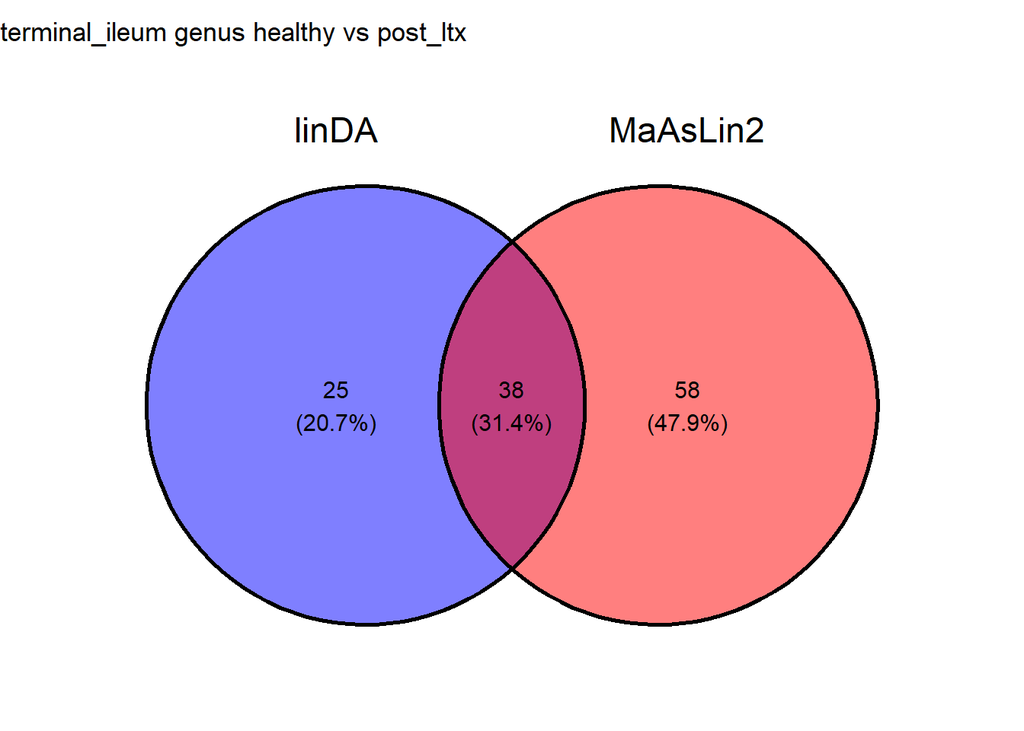

```r
intersection_results <- group_intersection(group, list_intersections, list_venns,
                                           linda.output, fit_data,
                                           raw_linda_results_genus,
                                           segment = segment,
                                           level=level)

list_intersections <- intersection_results[[1]]
list_venns <- intersection_results[[2]]
venn <- intersection_results[[3]]

# show the results
venn
```

##### Interaction effect

```r
list_interaction_significant <- country_interaction(group,
                                                    linda.output,
                                                    list_intersections,
                                          filt_ileum_uni_data,
                                          filt_ileum_uni_metadata,
                                          segment=segment,
                                          level=level)

# see the result
## significant interaction effect
list_interaction_significant[[1]]
```

```r
## results for czech cohort
list_interaction_significant[[2]]
```

```
## [1] NA
```

```r
## results for norwegian cohort
list_interaction_significant[[3]]
```

```
## [1] NA
```

Removing problematic taxa

```r
list_intersections <- removing_interaction_problems(group,
                                                    list_interaction_significant,
                                                    list_intersections,
                                                    segment=segment,
                                                    level=level)
```

##### Basic statistics

```r
uni_df <-  merge(basic_univariate_statistics(linda_data,group),
                 raw_linda_results_genus[[segment]][[group1]],
                 by="SeqID",all=TRUE)
```

```
## [1] "healthy"
## [1] "post_ltx"
## [1] "healthy"
## [1] "post_ltx"
```

```r
uni_df[["final_sig"]] <- uni_df$SeqID %in% list_intersections[[paste(segment,level,comparison_name)]][["SeqID"]]
uni_statistics[[segment]][[paste(level,comparison_name)]] <- uni_df

# for comparison
new_name <- comparison_name
addWorksheet(wb, sheetName = new_name)
writeData(wb, sheet = new_name, uni_df, rowNames=FALSE)
```

#### Visualization

```r
list_heatmap <- list_intersections[grep(paste(segment,level),
                                  names(list_intersections),value=TRUE)]

p_heatmap_linda <- heatmap_linda(list_heatmap,ileum_taxa_tab)
p_heatmap_linda
```

**Dot heatmap**

```r
dotheatmap_linda <- dot_heatmap_linda(list_heatmap,
                                      uni_statistics$terminal_ileum[grepl(level,names(uni_statistics$terminal_ileum))],
                                      ileum_taxa_tab) + xlab("") + ylab("")
```

```
## min_clr -1.767585
## max_clr 6.908912
## min_log -5.062147
## max_log 4.892498
```

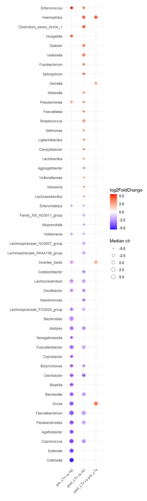

```r
dotheatmap_linda
```

**Horizontal bar plot**

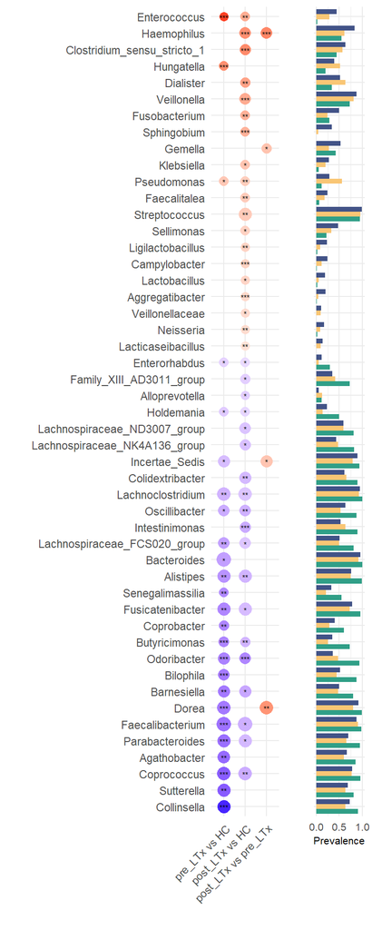

```r
p_prevalence <- horizontal_barplot(wb,taxa=levels(dotheatmap_linda$data$SeqID))
p_prevalence_final <- ggarrange(p_prevalence,
                                ggplot() + theme_minimal(),
                                nrow = 2,heights = c(1,0.09))

p <- ggarrange(dotheatmap_linda + theme(legend.position = "none"),
               p_prevalence_final,
               ncol=2,widths = c(1,0.3))
p
```

```r
dot_heatmap_ileum <- p
```

#### PSC effect

**pre_LTx vs HC and Post_LTx vs HC intersection**

```r
A <- list_intersections[[paste(segment,level,"healthy vs pre_ltx")]]$SeqID
B <- list_intersections[[paste(segment,level,"healthy vs post_ltx")]]$SeqID
C <- intersect(A,B)

psc_effect[[paste(segment,level)]] <- list_intersections[[paste(segment,level, "healthy vs pre_ltx")]][list_intersections[[paste(segment,level, "healthy vs pre_ltx")]]$SeqID %in% C,]

# see the results
psc_effect[[paste(segment,level)]]
```

|  | SeqID | Taxonomy | log2FoldChange | p_value | padj |
| --- | --- | --- | --- | --- | --- |
| 10 | Enterorhabdus | k__Bacteria;p__Actinobacteriota;c__Coriobacteriia;o__Coriobacteriales;f__Eggerthellaceae;g__Enterorhabdus | -1.050549 | 1.087023e-02 | 4.545734e-02 |
| 16 | Barnesiella | k__Bacteria;p__Bacteroidota;c__Bacteroidia;o__Bacteroidales;f__Barnesiellaceae;g__Barnesiella | -3.177161 | 1.263665e-03 | 7.750481e-03 |
| 19 | Butyricimonas | k__Bacteria;p__Bacteroidota;c__Bacteroidia;o__Bacteroidales;f__Marinifilaceae;g__Butyricimonas | -2.900425 | 6.571752e-05 | 9.301556e-04 |
| 20 | Odoribacter | k__Bacteria;p__Bacteroidota;c__Bacteroidia;o__Bacteroidales;f__Marinifilaceae;g__Odoribacter | -2.971657 | 3.696980e-05 | 6.184040e-04 |
| 27 | Alistipes | k__Bacteria;p__Bacteroidota;c__Bacteroidia;o__Bacteroidales;f__Rikenellaceae;g__Alistipes | -2.559742 | 5.731016e-04 | 4.336862e-03 |
| 29 | Parabacteroides | k__Bacteria;p__Bacteroidota;c__Bacteroidia;o__Bacteroidales;f__Tannerellaceae;g__Parabacteroides | -3.418185 | 1.366753e-05 | 2.794251e-04 |
| 41 | Holdemania | k__Bacteria;p__Firmicutes;c__Bacilli;o__Erysipelotrichales;f__Erysipelotrichaceae;g__Holdemania | -1.213660 | 1.082333e-02 | 4.545734e-02 |
| 64 | Coprococcus | k__Bacteria;p__Firmicutes;c__Clostridia;o__Lachnospirales;f__Lachnospiraceae;g__Coprococcus | -3.868534 | 6.688508e-07 | 3.076714e-05 |
| 68 | Fusicatenibacter | k__Bacteria;p__Firmicutes;c__Clostridia;o__Lachnospirales;f__Lachnospiraceae;g__Fusicatenibacter | -2.864295 | 5.224510e-04 | 4.336862e-03 |
| 72 | Lachnoclostridium | k__Bacteria;p__Firmicutes;c__Clostridia;o__Lachnospirales;f__Lachnospiraceae;g__Lachnoclostridium | -1.781011 | 1.555333e-03 | 9.231654e-03 |

[output cut: 5 more lines]

#### Saving results

```r
# ALL DATA
saveWorkbook(wb,file.path(path,paste0("uni_analysis_wb_",segment,".xlsx")),
             overwrite = TRUE)

# PSC effect
write.xlsx(psc_effect[[paste(segment,level)]],file.path(path,paste0("psc_effect_",segment,".xlsx")))

# SIGNIFICANT taxa

write.xlsx(list_intersections[grepl(segment,names(list_intersections))] %>%
            `names<-`(gsub(segment, "", names(
              list_intersections[grepl(segment,names(list_intersections))]))),
           file.path(path,paste0("significant_taxa_",segment,".xlsx")))
```

### Supplementary Analysis

```r
supplements_uni <- list()
supplements_wb <- createWorkbook()
```

#### ASV level

```r
level="ASV"
```

```r
path_maaslin="../intermediate_files/maaslin/Q1/ASV/"
```

```r
raw_linda_results <- list();
raw_linda_results[[segment]] <- list()
linda_results <- list();
linda_results[[segment]] <- list()
```

##### pre_ltx vs healthy

```r
group <- c("healthy","pre_ltx")
comparison_name <- paste0(group[1], " vs ",group[2])
```

**linDA**

```r
# prepare the data
linda_data <- binomial_prep(ileum_asv_tab,
                            ileum_taxa_tab,
                            ileum_metadata,
                            group, usage="linDA")
```

```
## Removing 1598 ASV(s)
```

```
## Removing 146 ASV(s)
```

```r
filt_ileum_uni_data <- linda_data[[1]]
filt_ileum_uni_taxa <- linda_data[[2]]
filt_ileum_uni_metadata <- linda_data[[3]]

# fit the model
linda.obj <- linda(filt_ileum_uni_data,
                   filt_ileum_uni_metadata,
                   formula = '~ Group * Country')
```

```
## 0  features are filtered!
## The filtered data has  143  samples and  453  features will be tested!
## Imputation approach is used.
## Fit linear models ...
## Completed.
```

```r
linda.output <- linda.obj$output
linda.output <- linda_renaming(linda.output, group)

# save the results
group1 <- paste0(group[1], " vs ","Group",group[2])
group2 <- paste0(group[1], " , ",group[2], " - CZ vs NO")
group3 <- paste0(group[1], " vs ","Group",group[2], ":CountryNO")

for (grp in c(group1,group2,group3)){
  raw_linda_results[[segment]][[grp]] <-
    rawlinda.df(linda.output,
                grp,
                filt_ileum_uni_data,
                filt_ileum_uni_taxa)

  linda_results[[segment]][[grp]] <-
    linda.df(linda.output,
             grp,
             filt_ileum_uni_data,
             filt_ileum_uni_taxa)
}
```

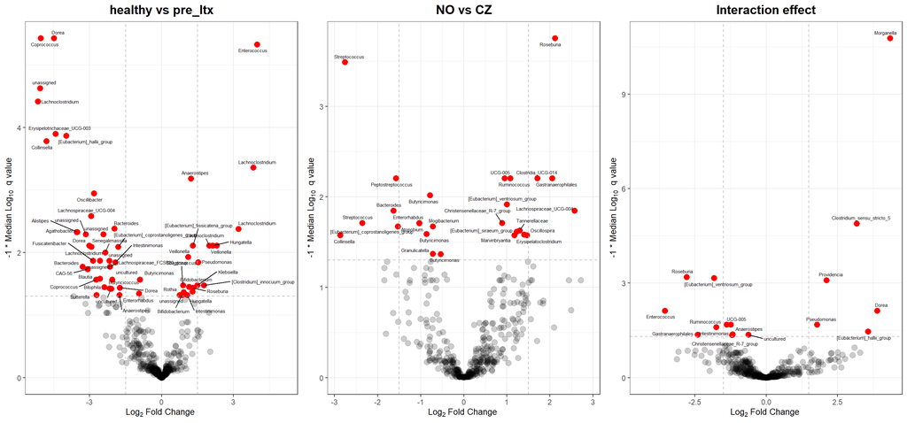

```r
# volcano plot
volcano_1 <- volcano_plot_linda(linda.output,
                                group1,
                                taxa_table = filt_ileum_uni_taxa) +
            ggtitle(comparison_title)

volcano_2  <- volcano_plot_linda(linda.output, group2,
                                taxa_table = filt_ileum_uni_taxa) +
            ggtitle("NO vs CZ")

volcano_3 <- volcano_plot_linda(linda.output, group3,
                                taxa_table = filt_ileum_uni_taxa) +
            ggtitle("Interaction effect")

volcano <- ggarrange(volcano_1,volcano_2,volcano_3, ncol=3)
volcano
```

**MaAsLin2**

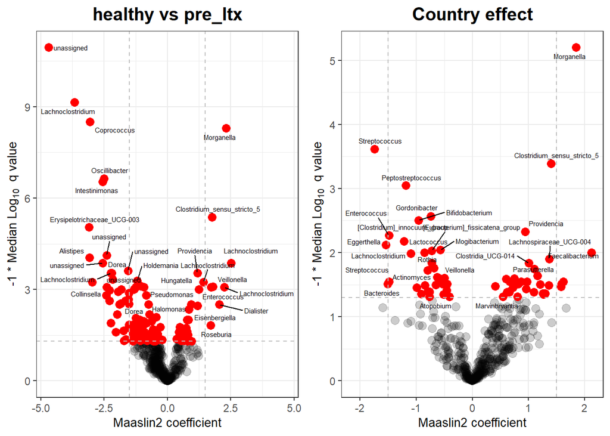

```r
volcano1 <- volcano_plot_maaslin(fit_data,filt_ileum_uni_taxa) +
            ggtitle(comparison_title)

volcano2 <- volcano_plot_maaslin(fit_data,filt_ileum_uni_taxa,variable="Country") +
            ggtitle("Country effect")

volcano <- ggarrange(volcano1,volcano2, ncol=2)
volcano
```

**Group - Intersection**

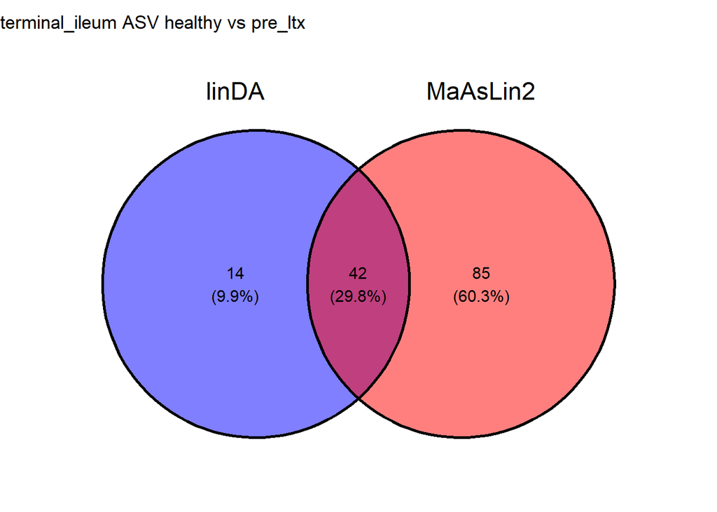

```r
intersection_results <- group_intersection(group, list_intersections, list_venns,
                                           linda.output, fit_data,
                                           raw_linda_results,
                                           segment = segment,
                                           level=level)

list_intersections <- intersection_results[[1]]
list_venns <- intersection_results[[2]]
venn <- intersection_results[[3]]

# show the results
venn
```

**Interaction effect**

```r
list_interaction_significant <- country_interaction(group,
                                                    linda.output,
                                                    list_intersections,
                                          filt_ileum_uni_data,
                                          filt_ileum_uni_metadata,
                                          segment=segment,
                                          level=level)

# see the result
## significant interaction effect
list_interaction_significant[[1]]
```

```r
## results for czech cohort
list_interaction_significant[[2]]
```

```
## [1] NA
```

```r
## results for norwegian cohort
list_interaction_significant[[3]]
```

```
## [1] NA
```

**Removing problematic taxa**

```r
list_intersections <- removing_interaction_problems(group,
                                                    list_interaction_significant,
                                                    list_intersections,
                                                    segment=segment,
                                                    level=level)
```

**Basic statistics**

```r
uni_df <-  merge(basic_univariate_statistics(linda_data,group),
                 raw_linda_results[[segment]][[group1]],
                 by="SeqID",all=TRUE)
```

```
## [1] "healthy"
## [1] "pre_ltx"
## [1] "healthy"
## [1] "pre_ltx"
```

```r
uni_df[["final_sig"]] <- uni_df$SeqID %in% list_intersections[[paste(segment,level,comparison_name)]][["SeqID"]]
uni_statistics[[segment]][[paste(level,comparison_name)]] <- uni_df

# for comparison
new_name <- paste(level,comparison_name)
addWorksheet(supplements_wb, sheetName = new_name)
writeData(supplements_wb, sheet = new_name, uni_df, rowNames=FALSE)
```

##### pre_ltx vs post_ltx

```r
group <- c("pre_ltx","post_ltx")
comparison_name <- paste0(group[1], " vs ",group[2])
```

**linDA**

```r
# prepare the data
linda_data <- binomial_prep(ileum_asv_tab,
                            ileum_taxa_tab,
                            ileum_metadata,
                            group, usage="linDA")
```

```
## Removing 979 ASV(s)
```

```
## Removing 68 ASV(s)
```

```r
filt_ileum_uni_data <- linda_data[[1]]
filt_ileum_uni_taxa <- linda_data[[2]]
filt_ileum_uni_metadata <- linda_data[[3]]

# fit the model
linda.obj <- linda(filt_ileum_uni_data,
                   filt_ileum_uni_metadata,
                   formula = '~ Group * Country')
```

```
## 0  features are filtered!
## The filtered data has  208  samples and  349  features will be tested!
## Imputation approach is used.
## Fit linear models ...
## Completed.
```

```r
linda.output <- linda.obj$output
linda.output <- linda_renaming(linda.output, group)

# save the results
group1 <- paste0(group[1], " vs ","Group",group[2])
group2 <- paste0(group[1], " , ",group[2], " - CZ vs NO")
group3 <- paste0(group[1], " vs ","Group",group[2], ":CountryNO")

for (grp in c(group1,group2,group3)){
  raw_linda_results[[segment]][[grp]] <-
    rawlinda.df(linda.output,
                grp,
                filt_ileum_uni_data,
                filt_ileum_uni_taxa)

  linda_results[[segment]][[grp]] <-
    linda.df(linda.output,
             grp,
             filt_ileum_uni_data,
             filt_ileum_uni_taxa)
}
```

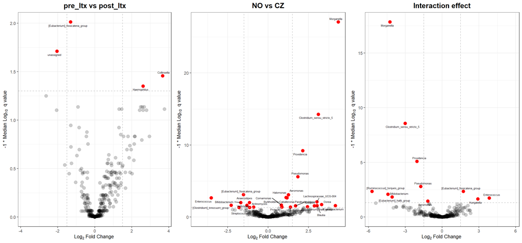

```r
# volcano plot
volcano_1 <- volcano_plot_linda(linda.output,
                                group1,
                                taxa_table = filt_ileum_uni_taxa) +
            ggtitle(comparison_title)

volcano_2  <- volcano_plot_linda(linda.output, group2,
                                taxa_table = filt_ileum_uni_taxa) +
            ggtitle("NO vs CZ")

volcano_3 <- volcano_plot_linda(linda.output, group3,
                                taxa_table = filt_ileum_uni_taxa) +
            ggtitle("Interaction effect")

volcano <- ggarrange(volcano_1,volcano_2,volcano_3, ncol=3)
volcano
```

**MaAsLin2**

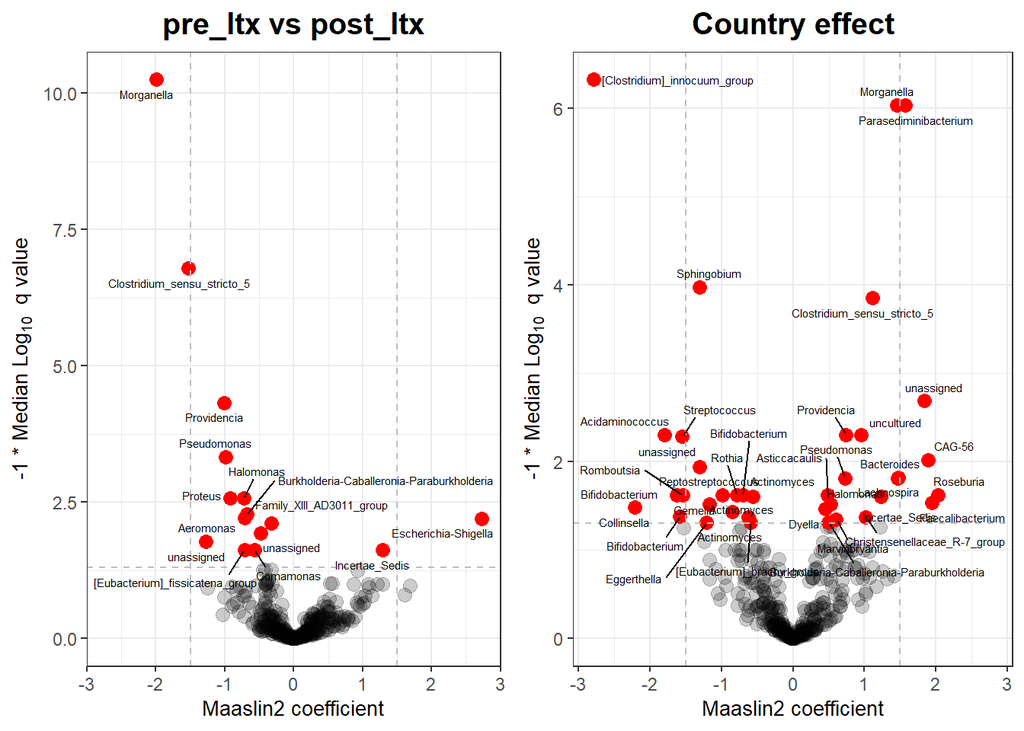

```r
volcano1 <- volcano_plot_maaslin(fit_data,filt_ileum_uni_taxa) +
            ggtitle(comparison_title)

volcano2 <- volcano_plot_maaslin(fit_data,filt_ileum_uni_taxa,variable="Country") +
            ggtitle("Country effect")

volcano <- ggarrange(volcano1,volcano2, ncol=2)
volcano
```

**Group - Intersection**

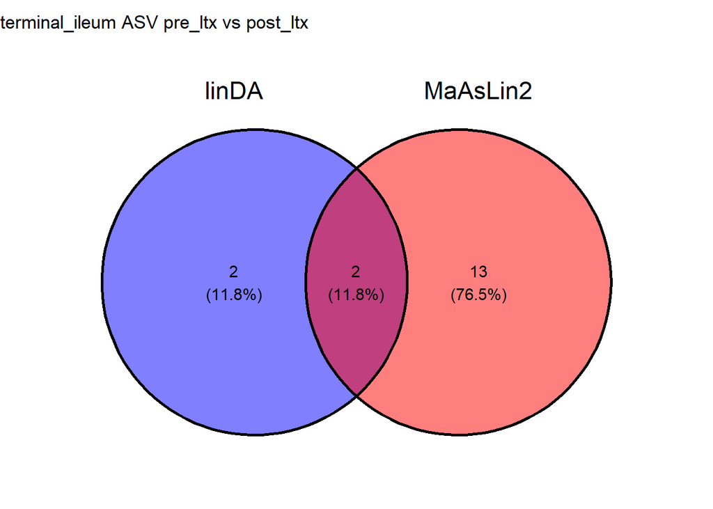

```r
intersection_results <- group_intersection(group, list_intersections, list_venns,
                                           linda.output, fit_data,
                                           raw_linda_results,
                                           segment = segment,
                                           level=level)

list_intersections <- intersection_results[[1]]
list_venns <- intersection_results[[2]]
venn <- intersection_results[[3]]

# show the results
venn
```

**Interaction effect**

```r
list_interaction_significant <- country_interaction(group,
                                                    linda.output,
                                                    list_intersections,
                                          filt_ileum_uni_data,
                                          filt_ileum_uni_metadata,
                                          segment=segment,
                                          level=level)

# see the result
## significant interaction effect
list_interaction_significant[[1]]
```

```r
## results for czech cohort
list_interaction_significant[[2]]
```

```
## [1] NA
```

```r
## results for norwegian cohort
list_interaction_significant[[3]]
```

```
## [1] NA
```

**Removing problematic taxa**

```r
list_intersections <- removing_interaction_problems(group,
                                                    list_interaction_significant,
                                                    list_intersections,
                                                    segment=segment,
                                                    level=level)
```

**Basic statistics**

```r
uni_df <-  merge(basic_univariate_statistics(linda_data,group),
                 raw_linda_results[[segment]][[group1]],
                 by="SeqID",all=TRUE)
```

```
## [1] "pre_ltx"
## [1] "post_ltx"
## [1] "pre_ltx"
## [1] "post_ltx"
```

```r
uni_df[["final_sig"]] <- uni_df$SeqID %in% list_intersections[[paste(segment,level,comparison_name)]][["SeqID"]]
uni_statistics[[segment]][[paste(level,comparison_name)]] <- uni_df

# for comparison
new_name <- paste(level,comparison_name)
addWorksheet(supplements_wb, sheetName = new_name)
writeData(supplements_wb, sheet = new_name, uni_df, rowNames=FALSE)
```

##### post_ltx vs healthy

```r
group <- c("healthy","post_ltx")
comparison_name <- paste0(group[1], " vs ",group[2])
```

**linDA**

```r
# prepare the data
linda_data <- binomial_prep(ileum_asv_tab,
                            ileum_taxa_tab,
                            ileum_metadata,
                            group, usage="linDA")
```

```
## Removing 641 ASV(s)
```

```
## Removing 104 ASV(s)
```

```r
filt_ileum_uni_data <- linda_data[[1]]
filt_ileum_uni_taxa <- linda_data[[2]]
filt_ileum_uni_metadata <- linda_data[[3]]

# fit the model
linda.obj <- linda(filt_ileum_uni_data,
                   filt_ileum_uni_metadata,
                   formula = '~ Group * Country')
```

```
## 0  features are filtered!
## The filtered data has  211  samples and  444  features will be tested!
## Pseudo-count approach is used.
## Fit linear models ...
## Completed.
```

```r
linda.output <- linda.obj$output
linda.output <- linda_renaming(linda.output, group)

# save the results
group1 <- paste0(group[1], " vs ","Group",group[2])
group2 <- paste0(group[1], " , ",group[2], " - CZ vs NO")
group3 <- paste0(group[1], " vs ","Group",group[2], ":CountryNO")

for (grp in c(group1,group2,group3)){
  raw_linda_results[[segment]][[grp]] <-
    rawlinda.df(linda.output,
                grp,
                filt_ileum_uni_data,
                filt_ileum_uni_taxa)

  linda_results[[segment]][[grp]] <-
    linda.df(linda.output,
             grp,
             filt_ileum_uni_data,
             filt_ileum_uni_taxa)
}
```

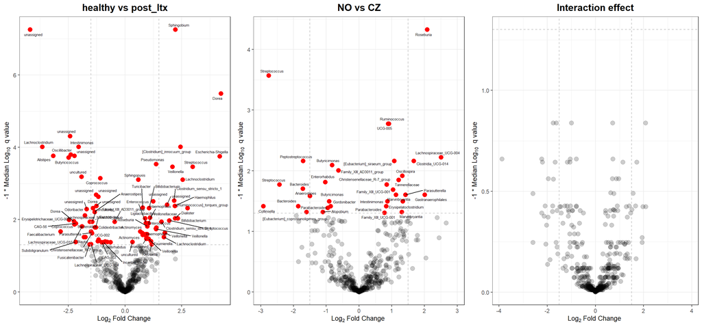

```r
# volcano plot
volcano_1 <- volcano_plot_linda(linda.output,
                                group1,
                                taxa_table = filt_ileum_uni_taxa) +
            ggtitle(comparison_title)

volcano_2  <- volcano_plot_linda(linda.output, group2,
                                taxa_table = filt_ileum_uni_taxa) +
            ggtitle("NO vs CZ")

volcano_3 <- volcano_plot_linda(linda.output, group3,
                                taxa_table = filt_ileum_uni_taxa) +
            ggtitle("Interaction effect")

volcano <- ggarrange(volcano_1,volcano_2,volcano_3, ncol=3)
volcano
```

**MaAsLin2**

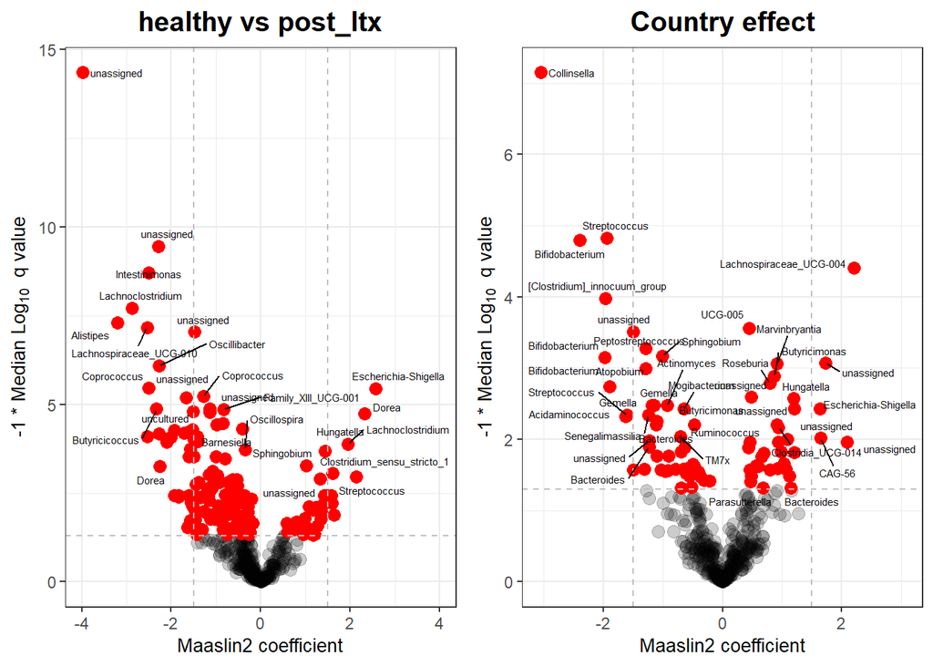

```r
volcano1 <- volcano_plot_maaslin(fit_data,filt_ileum_uni_taxa) +
            ggtitle(comparison_title)

volcano2 <- volcano_plot_maaslin(fit_data,filt_ileum_uni_taxa,variable="Country") +
            ggtitle("Country effect")

volcano <- ggarrange(volcano1,volcano2, ncol=2)
volcano
```

**Group - Intersection**

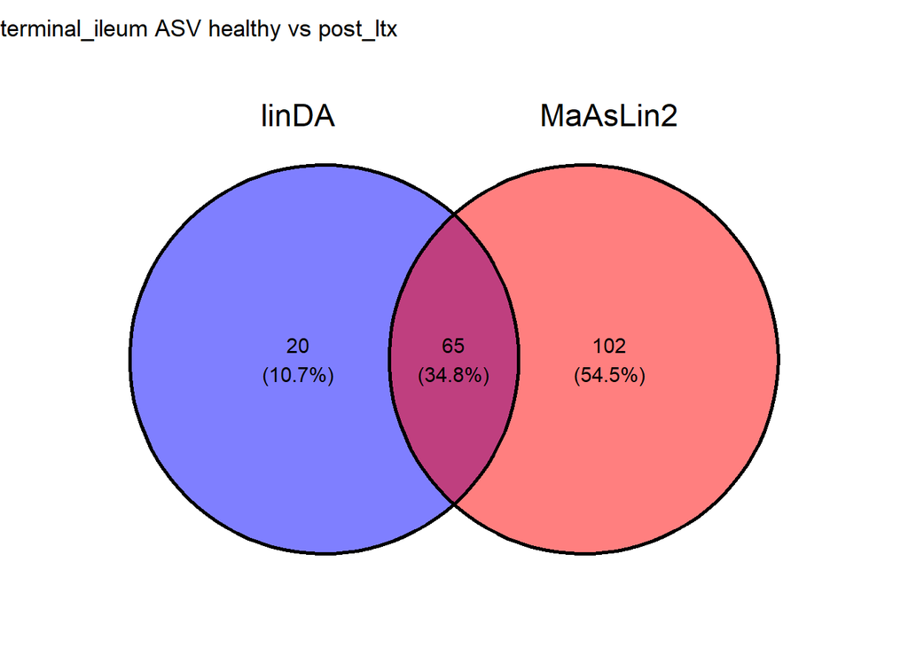

```r
intersection_results <- group_intersection(group, list_intersections, list_venns,
                                           linda.output, fit_data,
                                           raw_linda_results,
                                           segment = segment,
                                           level=level)

list_intersections <- intersection_results[[1]]
list_venns <- intersection_results[[2]]
venn <- intersection_results[[3]]

# show the results
venn
```

**Interaction effect**

```r
list_interaction_significant <- country_interaction(group,
                                                    linda.output,
                                                    list_intersections,
                                          filt_ileum_uni_data,
                                          filt_ileum_uni_metadata,
                                          segment=segment,
                                          level=level)

# see the result
## significant interaction effect
list_interaction_significant[[1]]
```

```r
## results for czech cohort
list_interaction_significant[[2]]
```

```
## [1] NA
```

```r
## results for norwegian cohort
list_interaction_significant[[3]]
```

```
## [1] NA
```

**Removing problematic taxa**

```r
list_intersections <- removing_interaction_problems(group,
                                                    list_interaction_significant,
                                                    list_intersections,
                                                    segment=segment,
                                                    level=level)
```

**Basic statistics**

```r
uni_df <-  merge(basic_univariate_statistics(linda_data,group),
                 raw_linda_results[[segment]][[group1]],
                 by="SeqID",all=TRUE)
```

```
## [1] "healthy"
## [1] "post_ltx"
## [1] "healthy"
## [1] "post_ltx"
```

```r
uni_df[["final_sig"]] <- uni_df$SeqID %in% list_intersections[[paste(segment,level,comparison_name)]][["SeqID"]]
uni_statistics[[segment]][[paste(level,comparison_name)]] <- uni_df

# for comparison
new_name <- paste(level,comparison_name)
addWorksheet(supplements_wb, sheetName = new_name)
writeData(supplements_wb, sheet = new_name, uni_df, rowNames=FALSE)
```

##### Visualization

```r
list_heatmap <- list_intersections[grep(paste(segment,level),
                                  names(list_intersections),value=TRUE)]

p_heatmap_linda <- heatmap_linda(list_heatmap,ileum_taxa_tab)
p_heatmap_linda
```

**Dot heatmap**

```r
dotheatmap_linda <- dot_heatmap_linda(list_heatmap,
                                      uni_statistics$terminal_ileum[grepl(level,names(uni_statistics$terminal_ileum))],
                                      ileum_taxa_tab)
```

```
## min_clr -1.065303
## max_clr 4.679688
## min_log -5.165415
## max_log 4.224397
```

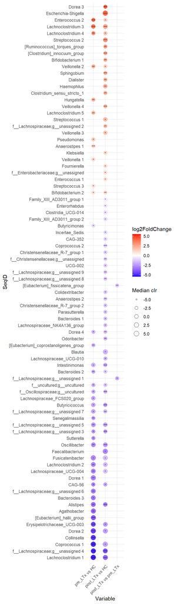

```r
dotheatmap_linda
```

##### PSC effect

**pre_LTx vs Healthy and Post_LTx vs Healthy intersection**

```r
A <- list_intersections[[paste(segment,level,"healthy vs pre_ltx")]]$SeqID
B <- list_intersections[[paste(segment,level,"healthy vs post_ltx")]]$SeqID
C <- intersect(A,B)

psc_effect[[paste(segment,level)]] <- list_intersections[[paste(segment,level, "healthy vs pre_ltx")]][list_intersections[[paste(segment,level, "healthy vs pre_ltx")]]$SeqID %in% C,]

# see the results
psc_effect[[paste(segment,level)]]
```

|  | SeqID | Taxonomy | log2FoldChange | p_value | padj |
| --- | --- | --- | --- | --- | --- |
| 22 | TAGGGAATTTTCGGCAATGGGGGAAACCCTGACCGAGCAACGCCGCGTGAAGGAAGAAGT…… | k__Bacteria;p__Firmicutes;c__Bacilli;o__Erysipelotrichales;f__Erysipelatoclostridiaceae;g__Erysipelotrichaceae_UCG-003;s__unassigned | -4.4298696 | 1.676032e-06 | 1.265404e-04 |
| 39 | TGAGGAATATTGGGCAATGGAGGAAACTCTGACCCAGCCATGCCGCGTGAGTGAAGAAGG…… | k__Bacteria;p__Proteobacteria;c__Alphaproteobacteria;o__Rhodospirillales;f__uncultured;g__uncultured;s__unassigned | -2.0538259 | 2.203655e-03 | 2.697988e-02 |
| 70 | TGAGGAATATTGGTCAATGGACGCAAGTCTGAACCAGCCATGCCGCGTGCAGGATGACGG…… | k__Bacteria;p__Bacteroidota;c__Bacteroidia;o__Bacteroidales;f__Rikenellaceae;g__Alistipes;s__unassigned | -3.5115154 | 1.659708e-04 | 4.699048e-03 |
| 83 | TGAGGAATATTGGTCAATGGGCGAGAGCCTGAACCAGCCAAGTAGCGTGAAGGATGAAGG…… | k__Bacteria;p__Bacteroidota;c__Bacteroidia;o__Bacteroidales;f__Bacteroidaceae;g__Bacteroides;s__unassigned | -1.9687275 | 1.190853e-04 | 4.149666e-03 |
| 133 | TGGGGAATATTGCACAATGGGCGAAAGCCTGATGCAGCAACGCCGCGTGAGTGAAGAAGT…… | k__Bacteria;p__Firmicutes;c__Clostridia;o__Lachnospirales;f__Lachnospiraceae;g__Lachnoclostridium;s__unassigned | -5.1654153 | 4.258197e-07 | 3.857926e-05 |
| 134 | TGGGGAATATTGCACAATGGGCGAAAGCCTGATGCAGCGACGCCGCGTGAAGGATGAAGT…… | k__Bacteria;p__Firmicutes;c__Clostridia;o__Lachnospirales;f__Lachnospiraceae;g__Dorea;s__unassigned | -4.4957248 | 1.521108e-08 | 3.757406e-06 |
| 139 | TGGGGAATATTGCACAATGGGCGAAAGCCTGATGCAGCGACGCCGCGTGAGTGAAGAAGT…… | k__Bacteria;p__Firmicutes;c__Clostridia;o__Lachnospirales;f__Lachnospiraceae;g__Lachnoclostridium;s__unassigned | -2.9269443 | 4.470062e-04 | 8.099752e-03 |
| 140 | TGGGGAATATTGCACAATGGGCGAAAGCCTGATGCAGCGACGCCGCGTGAGTGAAGAAGT…… | k__Bacteria;p__Firmicutes;c__Clostridia;o__Lachnospirales;f__Lachnospiraceae;g__Lachnoclostridium;s__unassigned | 3.8241704 | 8.725084e-06 | 4.391626e-04 |
| 141 | TGGGGAATATTGCACAATGGGCGAAAGCCTGATGCAGCGACGCCGCGTGAGTGAAGAAGT…… | k__Bacteria;p__Firmicutes;c__Clostridia;o__Lachnospirales;f__Lachnospiraceae;g__Lachnoclostridium;s__unassigned | 3.2182184 | 1.288509e-04 | 4.169248e-03 |
| 166 | TGGGGAATATTGCACAATGGGGGAAACCCTGATGCAGCAACGCCGCGTGAGTGAAGAAGT…… | k__Bacteria;p__Firmicutes;c__Clostridia;o__Lachnospirales;f__Lachnospiraceae;g__unassigned;s__unassigned | -2.5678980 | 8.934631e-04 | 1.349129e-02 |

[output cut: 15 more lines]

#### Phylum level

```r
level="phylum"
```

```r
path_maaslin="../intermediate_files/maaslin/Q1/Phylum/"
```

```r
raw_linda_results_phylum <- list();
raw_linda_results_phylum[[segment]] <- list()
linda_results_phylum <- list();
linda_results_phylum[[segment]] <- list()
```

Aggregate taxa

```r
phylum_data <- aggregate_taxa(ileum_asv_tab,
                             ileum_taxa_tab,
                             taxonomic_level = "Phylum")

ileum_phylum_tab <- phylum_data[[1]]
ileum_phylum_taxa_tab <- phylum_data[[2]]
```